# Datascience lecturenote

### Dataframe & List

```r
#Dataframe
str(mtcars)
```

```
## 'data.frame':    32 obs. of  11 variables:
##  $ mpg : num  21 21 22.8 21.4 18.7 18.1 14.3 24.4 22.8 19.2 ...
##  $ cyl : num  6 6 4 6 8 6 8 4 4 6 ...
##  $ disp: num  160 160 108 258 360 ...
##  $ hp  : num  110 110 93 110 175 105 245 62 95 123 ...
##  $ drat: num  3.9 3.9 3.85 3.08 3.15 2.76 3.21 3.69 3.92 3.92 ...
##  $ wt  : num  2.62 2.88 2.32 3.21 3.44 ...
##  $ qsec: num  16.5 17 18.6 19.4 17 ...
##  $ vs  : num  0 0 1 1 0 1 0 1 1 1 ...
##  $ am  : num  1 1 1 0 0 0 0 0 0 0 ...
##  $ gear: num  4 4 4 3 3 3 3 4 4 4 ...
##  $ carb: num  4 4 1 1 2 1 4 2 2 4 ...
```

```r
dim(mtcars)
```

```
## [1] 32 11
```

```r
head(mtcars)
```

```
##                    mpg cyl disp  hp drat    wt  qsec vs am gear carb
## Mazda RX4         21.0   6  160 110 3.90 2.620 16.46  0  1    4    4
## Mazda RX4 Wag     21.0   6  160 110 3.90 2.875 17.02  0  1    4    4
## Datsun 710        22.8   4  108  93 3.85 2.320 18.61  1  1    4    1
## Hornet 4 Drive    21.4   6  258 110 3.08 3.215 19.44  1  0    3    1
## Hornet Sportabout 18.7   8  360 175 3.15 3.440 17.02  0  0    3    2
## Valiant           18.1   6  225 105 2.76 3.460 20.22  1  0    3    1
```

```r
mtcars$mpg >20
```

```
##  [1]  TRUE  TRUE  TRUE  TRUE FALSE FALSE FALSE  TRUE  TRUE FALSE FALSE FALSE
## [13] FALSE FALSE FALSE FALSE FALSE  TRUE  TRUE  TRUE  TRUE FALSE FALSE FALSE
## [25] FALSE  TRUE  TRUE  TRUE FALSE FALSE FALSE  TRUE
```

```r
mtcars[mtcars$mpg>20,]#df[조건,(변수이름)]으로 select할 수 있음
```

```
##                 mpg cyl  disp  hp drat    wt  qsec vs am gear carb
## Mazda RX4      21.0   6 160.0 110 3.90 2.620 16.46  0  1    4    4
## Mazda RX4 Wag  21.0   6 160.0 110 3.90 2.875 17.02  0  1    4    4
## Datsun 710     22.8   4 108.0  93 3.85 2.320 18.61  1  1    4    1
## Hornet 4 Drive 21.4   6 258.0 110 3.08 3.215 19.44  1  0    3    1
## Merc 240D      24.4   4 146.7  62 3.69 3.190 20.00  1  0    4    2
## Merc 230       22.8   4 140.8  95 3.92 3.150 22.90  1  0    4    2
## Fiat 128       32.4   4  78.7  66 4.08 2.200 19.47  1  1    4    1
## Honda Civic    30.4   4  75.7  52 4.93 1.615 18.52  1  1    4    2
## Toyota Corolla 33.9   4  71.1  65 4.22 1.835 19.90  1  1    4    1
## Toyota Corona  21.5   4 120.1  97 3.70 2.465 20.01  1  0    3    1
## Fiat X1-9      27.3   4  79.0  66 4.08 1.935 18.90  1  1    4    1
## Porsche 914-2  26.0   4 120.3  91 4.43 2.140 16.70  0  1    5    2
## Lotus Europa   30.4   4  95.1 113 3.77 1.513 16.90  1  1    5    2
## Volvo 142E     21.4   4 121.0 109 4.11 2.780 18.60  1  1    4    2
```

```r
#List
my_list <- list('a'=a_vector,'starwars'=star_wars_matrix,'cars'=mtcars)
names(my_list) <- c('a','starwars','car')
#정보 부르는법 my_list[[1]] 1자리에 name,혹은 my_list$starwars
```

## 데이터과학 3주차 강의노트

### if문

if (condition) {exp}  
if (condition) {exp} else{exp}

### for문

for(var in seq){exp}

### ifelse문

ifelse(조건, ‘true일때결과’,‘False일때결과’)

### DataLoading

getwd() setwd(“경로”) ### Save & load csv로 저장 -> write.csv(저장 대상, “저장할 파일 이름.csv”, row.names = F or T,) tsv로 저장 -> write.csv(저장 대상, “저장할 파일 이름.tsv”, row.names = F or T, sep=’)

Rdata로 저장 & 불러오기 save(벡터,벡터,다른거, file=‘파일이름.Rdata’) load(‘파일이름’)

```r
#read.csv
getwd()
```

```
## [1] "C:/Users/user/Documents/github_Rstudio_workspace/Data"
```

```r
setwd("C:/Users/user/Documents/github_Rstudio_workspace/Data")
pools <- read.csv('swimming_pools.csv',stringsAsFactors = FALSE)
str(pools)
```

```
## 'data.frame':    20 obs. of  4 variables:
##  $ Name     : chr  "Acacia Ridge Leisure Centre" "Bellbowrie Pool" "Carole Park" "Centenary Pool (inner City)" ...
##  $ Address  : chr  "1391 Beaudesert Road, Acacia Ridge" "Sugarwood Street, Bellbowrie" "Cnr Boundary Road and Waterford Road Wacol" "400 Gregory Terrace, Spring Hill" ...
##  $ Latitude : num  -27.6 -27.6 -27.6 -27.5 -27.4 ...
##  $ Longitude: num  153 153 153 153 153 ...
```

```r
#read.table
hotdogs <- read.table('hotdog.txt',sep='\t',col.names = c('type','calories','sodium'))
hotdogs$cal.type <- ifelse(hotdogs$calories>150, 'heavy','light')#추가하고싶은변수그냥 냅다 설정하고 때려박으면됨
#Save
write.csv(hotdogs,file='newhotdogs.csv',row.names = F)
write.table(hotdogs,file='newhotdogs.tsv',row.names = F, sep='\t')
```

### 유용한 함수 사용

사용자 정의 함수 함수명 <- function(변수){return(출력값)}  
runif(개수) ->0~1 에 대해 난수생성하는것(set.seed(2018)등 숫자설정하면 난수가 똑같이나옴)  
apply(x,margin,function) margin -> 1=row, 2=column 즉 dataframe을 슬라이스내서 그걸로 함수적용하는것 * lapply(x,function) -> listapply라고 보면됨 * sapply(x,function) -> 결과가 벡터나 행렬로 나옴 #sapply(x,function(x){return값}) -> 익명 함수 * tapply는 행렬 기준임 tapply(다룰 백터, 그룹백터 혹은 그룹으로 나눌만한 조건, function) * aggregate(종속변수~독립변수, data=어떤데이터, function) * sort(백터, decreasing=T) * order(백터) 결과는 정렬되는 인덱스 백터가 나옴 **sort는 order을 내포하고 있음** * 즉 order는 기준을 설정하고 데이터 프레임 내 정렬할 때 쓰기 좋음 * sample(x,샘플개수,replace=False) * split(df, split_var) ->데이터 프레임을 어떤 기준으로 쪼개서 리스트로 나타내주는 것 * subset(dataframe, 조건) * merge(df1,df2) * which(조건) ->조건을 충족한 인덱스를 찾는것 위치를 찾는것 * cut(vector, breaks = c(0,2,4,6), label=c(1,2,3),right) -> 명목형 변수로 나타낼 때 * quantile->기본이 4분위수 하지만 probs로 내가 원하는 퍼센테이지 볼 수 있음 * paste 1. 문자끼리 붙이기 2. 벡터 인덱스 같은것끼리 붙이기

```r
#apply
tapply(iris$Sepal.Length, iris$Species, mean)
```

```
##     setosa versicolor  virginica
##      5.006      5.936      6.588
```

```r
tapply(mtcars$wt,mtcars$mpg>20, mean)
```

```
##    FALSE     TRUE
## 3.838833 2.418071
```

```r
#sort,order
sort(mtcars$mpg)
```

```
##  [1] 10.4 10.4 13.3 14.3 14.7 15.0 15.2 15.2 15.5 15.8 16.4 17.3 17.8 18.1 18.7
## [16] 19.2 19.2 19.7 21.0 21.0 21.4 21.4 21.5 22.8 22.8 24.4 26.0 27.3 30.4 30.4
## [31] 32.4 33.9
```

```r
order(mtcars$mpg)
```

```
##  [1] 15 16 24  7 17 31 14 23 22 29 12 13 11  6  5 10 25 30  1  2  4 32 21  3  9
## [26]  8 27 26 19 28 18 20
```

```r
mtcars[order(mtcars$mpg, decreasing=T),]
```

```
##                      mpg cyl  disp  hp drat    wt  qsec vs am gear carb
## Toyota Corolla      33.9   4  71.1  65 4.22 1.835 19.90  1  1    4    1
## Fiat 128            32.4   4  78.7  66 4.08 2.200 19.47  1  1    4    1
## Honda Civic         30.4   4  75.7  52 4.93 1.615 18.52  1  1    4    2
## Lotus Europa        30.4   4  95.1 113 3.77 1.513 16.90  1  1    5    2
## Fiat X1-9           27.3   4  79.0  66 4.08 1.935 18.90  1  1    4    1
## Porsche 914-2       26.0   4 120.3  91 4.43 2.140 16.70  0  1    5    2
## Merc 240D           24.4   4 146.7  62 3.69 3.190 20.00  1  0    4    2
## Datsun 710          22.8   4 108.0  93 3.85 2.320 18.61  1  1    4    1
## Merc 230            22.8   4 140.8  95 3.92 3.150 22.90  1  0    4    2
## Toyota Corona       21.5   4 120.1  97 3.70 2.465 20.01  1  0    3    1
## Hornet 4 Drive      21.4   6 258.0 110 3.08 3.215 19.44  1  0    3    1
## Volvo 142E          21.4   4 121.0 109 4.11 2.780 18.60  1  1    4    2
## Mazda RX4           21.0   6 160.0 110 3.90 2.620 16.46  0  1    4    4
## Mazda RX4 Wag       21.0   6 160.0 110 3.90 2.875 17.02  0  1    4    4
## Ferrari Dino        19.7   6 145.0 175 3.62 2.770 15.50  0  1    5    6
## Merc 280            19.2   6 167.6 123 3.92 3.440 18.30  1  0    4    4
## Pontiac Firebird    19.2   8 400.0 175 3.08 3.845 17.05  0  0    3    2
## Hornet Sportabout   18.7   8 360.0 175 3.15 3.440 17.02  0  0    3    2
## Valiant             18.1   6 225.0 105 2.76 3.460 20.22  1  0    3    1
## Merc 280C           17.8   6 167.6 123 3.92 3.440 18.90  1  0    4    4
## Merc 450SL          17.3   8 275.8 180 3.07 3.730 17.60  0  0    3    3
## Merc 450SE          16.4   8 275.8 180 3.07 4.070 17.40  0  0    3    3
## Ford Pantera L      15.8   8 351.0 264 4.22 3.170 14.50  0  1    5    4
## Dodge Challenger    15.5   8 318.0 150 2.76 3.520 16.87  0  0    3    2
## Merc 450SLC         15.2   8 275.8 180 3.07 3.780 18.00  0  0    3    3
## AMC Javelin         15.2   8 304.0 150 3.15 3.435 17.30  0  0    3    2
## Maserati Bora       15.0   8 301.0 335 3.54 3.570 14.60  0  1    5    8
## Chrysler Imperial   14.7   8 440.0 230 3.23 5.345 17.42  0  0    3    4
## Duster 360          14.3   8 360.0 245 3.21 3.570 15.84  0  0    3    4
## Camaro Z28          13.3   8 350.0 245 3.73 3.840 15.41  0  0    3    4
## Cadillac Fleetwood  10.4   8 472.0 205 2.93 5.250 17.98  0  0    3    4
## Lincoln Continental 10.4   8 460.0 215 3.00 5.424 17.82  0  0    3    4
```

```r
iris[order(iris$Petal.Length, decreasing=T),]
```

```
##     Sepal.Length Sepal.Width Petal.Length Petal.Width    Species
## 119          7.7         2.6          6.9         2.3  virginica
## 118          7.7         3.8          6.7         2.2  virginica
## 123          7.7         2.8          6.7         2.0  virginica
## 106          7.6         3.0          6.6         2.1  virginica
## 132          7.9         3.8          6.4         2.0  virginica
## 108          7.3         2.9          6.3         1.8  virginica
## 110          7.2         3.6          6.1         2.5  virginica
## 131          7.4         2.8          6.1         1.9  virginica
## 136          7.7         3.0          6.1         2.3  virginica
## 101          6.3         3.3          6.0         2.5  virginica
## 126          7.2         3.2          6.0         1.8  virginica
## 103          7.1         3.0          5.9         2.1  virginica
## 144          6.8         3.2          5.9         2.3  virginica
## 105          6.5         3.0          5.8         2.2  virginica
```

[output cut: 136 more lines]

```r
sample(1:150, 10,replace = FALSE)
```

```
##  [1]  89 146  43  26  13  96 103   2  53  63
```

```r
iris[sample(1:150, 10,replace = FALSE),]
```

```
##     Sepal.Length Sepal.Width Petal.Length Petal.Width    Species
## 147          6.3         2.5          5.0         1.9  virginica
## 89           5.6         3.0          4.1         1.3 versicolor
## 31           4.8         3.1          1.6         0.2     setosa
## 138          6.4         3.1          5.5         1.8  virginica
## 10           4.9         3.1          1.5         0.1     setosa
## 34           5.5         4.2          1.4         0.2     setosa
## 127          6.2         2.8          4.8         1.8  virginica
## 35           4.9         3.1          1.5         0.2     setosa
## 144          6.8         3.2          5.9         2.3  virginica
## 19           5.7         3.8          1.7         0.3     setosa
```

```r
sample(a_vector,length(a_vector))#순서섞는것도 가능
```

```
## [1] 8 1 2 5 3 2 7
```

```r
#split
split(mtcars,mtcars$cyl)
```

```
## $`4`
##                 mpg cyl  disp  hp drat    wt  qsec vs am gear carb
## Datsun 710     22.8   4 108.0  93 3.85 2.320 18.61  1  1    4    1
## Merc 240D      24.4   4 146.7  62 3.69 3.190 20.00  1  0    4    2
## Merc 230       22.8   4 140.8  95 3.92 3.150 22.90  1  0    4    2
## Fiat 128       32.4   4  78.7  66 4.08 2.200 19.47  1  1    4    1
## Honda Civic    30.4   4  75.7  52 4.93 1.615 18.52  1  1    4    2
## Toyota Corolla 33.9   4  71.1  65 4.22 1.835 19.90  1  1    4    1
## Toyota Corona  21.5   4 120.1  97 3.70 2.465 20.01  1  0    3    1
## Fiat X1-9      27.3   4  79.0  66 4.08 1.935 18.90  1  1    4    1
## Porsche 914-2  26.0   4 120.3  91 4.43 2.140 16.70  0  1    5    2
## Lotus Europa   30.4   4  95.1 113 3.77 1.513 16.90  1  1    5    2
## Volvo 142E     21.4   4 121.0 109 4.11 2.780 18.60  1  1    4    2
##
## $`6`
##                 mpg cyl  disp  hp drat    wt  qsec vs am gear carb
## Mazda RX4      21.0   6 160.0 110 3.90 2.620 16.46  0  1    4    4
## Mazda RX4 Wag  21.0   6 160.0 110 3.90 2.875 17.02  0  1    4    4
## Hornet 4 Drive 21.4   6 258.0 110 3.08 3.215 19.44  1  0    3    1
## Valiant        18.1   6 225.0 105 2.76 3.460 20.22  1  0    3    1
## Merc 280       19.2   6 167.6 123 3.92 3.440 18.30  1  0    4    4
## Merc 280C      17.8   6 167.6 123 3.92 3.440 18.90  1  0    4    4
## Ferrari Dino   19.7   6 145.0 175 3.62 2.770 15.50  0  1    5    6
##
## $`8`
##                      mpg cyl  disp  hp drat    wt  qsec vs am gear carb
## Hornet Sportabout   18.7   8 360.0 175 3.15 3.440 17.02  0  0    3    2
## Duster 360          14.3   8 360.0 245 3.21 3.570 15.84  0  0    3    4
## Merc 450SE          16.4   8 275.8 180 3.07 4.070 17.40  0  0    3    3
## Merc 450SL          17.3   8 275.8 180 3.07 3.730 17.60  0  0    3    3
## Merc 450SLC         15.2   8 275.8 180 3.07 3.780 18.00  0  0    3    3
## Cadillac Fleetwood  10.4   8 472.0 205 2.93 5.250 17.98  0  0    3    4
## Lincoln Continental 10.4   8 460.0 215 3.00 5.424 17.82  0  0    3    4
## Chrysler Imperial   14.7   8 440.0 230 3.23 5.345 17.42  0  0    3    4
## Dodge Challenger    15.5   8 318.0 150 2.76 3.520 16.87  0  0    3    2
## AMC Javelin         15.2   8 304.0 150 3.15 3.435 17.30  0  0    3    2
## Camaro Z28          13.3   8 350.0 245 3.73 3.840 15.41  0  0    3    4
## Pontiac Firebird    19.2   8 400.0 175 3.08 3.845 17.05  0  0    3    2
## Ford Pantera L      15.8   8 351.0 264 4.22 3.170 14.50  0  1    5    4
## Maserati Bora       15.0   8 301.0 335 3.54 3.570 14.60  0  1    5    8
```

```r
split(iris,iris$Petal.Width>2)
```

```
## $`FALSE`
##     Sepal.Length Sepal.Width Petal.Length Petal.Width    Species
## 1            5.1         3.5          1.4         0.2     setosa
## 2            4.9         3.0          1.4         0.2     setosa
## 3            4.7         3.2          1.3         0.2     setosa
## 4            4.6         3.1          1.5         0.2     setosa
## 5            5.0         3.6          1.4         0.2     setosa
## 6            5.4         3.9          1.7         0.4     setosa
## 7            4.6         3.4          1.4         0.3     setosa
## 8            5.0         3.4          1.5         0.2     setosa
## 9            4.4         2.9          1.4         0.2     setosa
## 10           4.9         3.1          1.5         0.1     setosa
## 11           5.4         3.7          1.5         0.2     setosa
## 12           4.8         3.4          1.6         0.2     setosa
## 13           4.8         3.0          1.4         0.1     setosa
```

[output cut: 140 more lines]

```r
#merge
x <- data.frame(name=c("john",'bob','carol'),
                math=c(70,80,90))
y <- data.frame(name=c('john','bob','alice'),
                history=c(100,80,90))
merge(x,y)
```

```
##   name math history
## 1  bob   80      80
## 2 john   70     100
```

```r
merge(x,y,all=T)
```

```
##    name math history
## 1   bob   80      80
## 2 carol   90      NA
## 3  john   70     100
## 4 alice   NA      90
```

```r
#cut
mtcars$wt
```

```
##  [1] 2.620 2.875 2.320 3.215 3.440 3.460 3.570 3.190 3.150 3.440 3.440 4.070
## [13] 3.730 3.780 5.250 5.424 5.345 2.200 1.615 1.835 2.465 3.520 3.435 3.840
## [25] 3.845 1.935 2.140 1.513 3.170 2.770 3.570 2.780
```

```r
cut(mtcars$wt,breaks = c(0,2,4,6), label=c(1,2,3), right=TRUE)
```

```
##  [1] 2 2 2 2 2 2 2 2 2 2 2 3 2 2 3 3 3 2 1 1 2 2 2 2 2 1 2 1 2 2 2 2
## Levels: 1 2 3
```

```r
#quantile
quantile(iris$Sepal.Length, probs = c(0.1,0.9))
```

```
## 10% 90%
## 4.8 6.9
```

```r
cutpoint <- quantile(mtcars$mpg,probs=c(0,0.25,0.75,1))
mtcars$fuelefficiency <- cut(mtcars$mpg,breaks=cutpoint,include.lowest = T)
#paste
x <- seq(2,20.2)
y <- LETTERS[1:10]
paste(x,y,sep = ';')
```

```
##  [1] "2;A"  "3;B"  "4;C"  "5;D"  "6;E"  "7;F"  "8;G"  "9;H"  "10;I" "11;J"
## [11] "12;A" "13;B" "14;C" "15;D" "16;E" "17;F" "18;G" "19;H" "20;I"
```

```r
paste(paste(x,y), collapse = ',')
```

```
## [1] "2 A,3 B,4 C,5 D,6 E,7 F,8 G,9 H,10 I,11 J,12 A,13 B,14 C,15 D,16 E,17 F,18 G,19 H,20 I"
```

```r
outcome <- 'mpg'
input_var <- names(mtcars)[2:6]
paste(outcome,paste(input_var,collapse='+'),sep = '~')
```

```
## [1] "mpg~cyl+disp+hp+drat+wt"
```

## 데이터과학4주차 강의노트

### Explore Data

```r
bmi<- read.csv("C:/Users/user/Documents/github_Rstudio_workspace/Data/bmi_clean.csv",header = TRUE)
str(bmi)
```

```
## 'data.frame':    199 obs. of  30 variables:
##  $ Country: Factor w/ 199 levels "Afghanistan",..: 1 2 3 4 5 6 7 8 9 10 ...
##  $ Y1980  : num  21.5 25.2 22.3 25.7 20.9 ...
##  $ Y1981  : num  21.5 25.2 22.3 25.7 20.9 ...
##  $ Y1982  : num  21.5 25.3 22.4 25.7 20.9 ...
##  $ Y1983  : num  21.4 25.3 22.5 25.8 20.9 ...
##  $ Y1984  : num  21.4 25.3 22.6 25.8 20.9 ...
##  $ Y1985  : num  21.4 25.3 22.7 25.9 20.9 ...
##  $ Y1986  : num  21.4 25.3 22.8 25.9 21 ...
##  $ Y1987  : num  21.4 25.3 22.8 25.9 21 ...
##  $ Y1988  : num  21.3 25.3 22.9 26 21 ...
##  $ Y1989  : num  21.3 25.3 23 26 21.1 ...
##  $ Y1990  : num  21.2 25.3 23 26.1 21.1 ...
##  $ Y1991  : num  21.2 25.3 23.1 26.2 21.1 ...
##  $ Y1992  : num  21.1 25.2 23.2 26.2 21.1 ...
```

[output cut: 16 more lines]

```r
dim(bmi)
```

```
## [1] 199  30
```

```r
names(bmi)
```

```
##  [1] "Country" "Y1980"   "Y1981"   "Y1982"   "Y1983"   "Y1984"   "Y1985"
##  [8] "Y1986"   "Y1987"   "Y1988"   "Y1989"   "Y1990"   "Y1991"   "Y1992"
## [15] "Y1993"   "Y1994"   "Y1995"   "Y1996"   "Y1997"   "Y1998"   "Y1999"
## [22] "Y2000"   "Y2001"   "Y2002"   "Y2003"   "Y2004"   "Y2005"   "Y2006"
## [29] "Y2007"   "Y2008"
```

```r
class(bmi)
```

```
## [1] "data.frame"
```

```r
summary(bmi)
```

```
##                 Country        Y1980           Y1981           Y1982
##  Afghanistan        :  1   Min.   :19.01   Min.   :19.04   Min.   :19.07
##  Albania            :  1   1st Qu.:21.27   1st Qu.:21.31   1st Qu.:21.36
##  Algeria            :  1   Median :23.31   Median :23.39   Median :23.46
##  Andorra            :  1   Mean   :23.15   Mean   :23.21   Mean   :23.26
##  Angola             :  1   3rd Qu.:24.82   3rd Qu.:24.89   3rd Qu.:24.94
##  Antigua and Barbuda:  1   Max.   :28.12   Max.   :28.36   Max.   :28.58
##  (Other)            :193
##      Y1983           Y1984           Y1985           Y1986
##  Min.   :19.10   Min.   :19.13   Min.   :19.16   Min.   :19.20
##  1st Qu.:21.42   1st Qu.:21.45   1st Qu.:21.47   1st Qu.:21.49
##  Median :23.57   Median :23.64   Median :23.73   Median :23.82
##  Mean   :23.32   Mean   :23.37   Mean   :23.42   Mean   :23.48
##  3rd Qu.:25.02   3rd Qu.:25.06   3rd Qu.:25.11   3rd Qu.:25.20
##  Max.   :28.82   Max.   :29.05   Max.   :29.28   Max.   :29.52
##
##      Y1987           Y1988           Y1989           Y1990
##  Min.   :19.23   Min.   :19.27   Min.   :19.31   Min.   :19.35
##  1st Qu.:21.50   1st Qu.:21.52   1st Qu.:21.55   1st Qu.:21.57
##  Median :23.87   Median :23.93   Median :24.03   Median :24.14
##  Mean   :23.53   Mean   :23.59   Mean   :23.65   Mean   :23.71
##  3rd Qu.:25.27   3rd Qu.:25.34   3rd Qu.:25.37   3rd Qu.:25.39
##  Max.   :29.75   Max.   :29.98   Max.   :30.20   Max.   :30.42
##
##      Y1991           Y1992           Y1993           Y1994
##  Min.   :19.40   Min.   :19.45   Min.   :19.51   Min.   :19.59
##  1st Qu.:21.60   1st Qu.:21.65   1st Qu.:21.74   1st Qu.:21.76
##  Median :24.20   Median :24.19   Median :24.27   Median :24.36
##  Mean   :23.76   Mean   :23.82   Mean   :23.88   Mean   :23.94
##  3rd Qu.:25.42   3rd Qu.:25.48   3rd Qu.:25.54   3rd Qu.:25.62
##  Max.   :30.64   Max.   :30.85   Max.   :31.04   Max.   :31.23
##
##      Y1995           Y1996           Y1997           Y1998
##  Min.   :19.67   Min.   :19.71   Min.   :19.74   Min.   :19.77
##  1st Qu.:21.83   1st Qu.:21.89   1st Qu.:21.94   1st Qu.:22.00
##  Median :24.41   Median :24.42   Median :24.50   Median :24.49
##  Mean   :24.00   Mean   :24.07   Mean   :24.14   Mean   :24.21
##  3rd Qu.:25.70   3rd Qu.:25.78   3rd Qu.:25.85   3rd Qu.:25.94
##  Max.   :31.41   Max.   :31.59   Max.   :31.77   Max.   :31.95
##
```

[output cut: 9 more lines]

```
##  Min.   :19.81   Min.   :19.79   Min.   :19.79   Min.   :19.80
##  1st Qu.:22.37   1st Qu.:22.45   1st Qu.:22.54   1st Qu.:22.63
##  Median :24.89   Median :25.00   Median :25.11   Median :25.24
##  Mean   :24.61   Mean   :24.70   Mean   :24.79   Mean   :24.89
##  3rd Qu.:26.38   3rd Qu.:26.47   3rd Qu.:26.53   3rd Qu.:26.59
##  Max.   :32.90   Max.   :33.10   Max.   :33.30   Max.   :33.49
##
##      Y2007           Y2008
##  Min.   :19.83   Min.   :19.87
##  1st Qu.:22.73   1st Qu.:22.83
##  Median :25.36   Median :25.50
##  Mean   :24.99   Mean   :25.10
##  3rd Qu.:26.66   3rd Qu.:26.82
##  Max.   :33.69   Max.   :33.90
##
```

```r
glimpse(bmi)
```

```
## Rows: 199
## Columns: 30
## $ Country <fct> Afghanistan, Albania, Algeria, Andorra, Angola, Antigua and...
## $ Y1980   <dbl> 21.48678, 25.22533, 22.25703, 25.66652, 20.94876, 23.31424,...
## $ Y1981   <dbl> 21.46552, 25.23981, 22.34745, 25.70868, 20.94371, 23.39054,...
## $ Y1982   <dbl> 21.45145, 25.25636, 22.43647, 25.74681, 20.93754, 23.45883,...
## $ Y1983   <dbl> 21.43822, 25.27176, 22.52105, 25.78250, 20.93187, 23.53735,...
## $ Y1984   <dbl> 21.42734, 25.27901, 22.60633, 25.81874, 20.93569, 23.63584,...
## $ Y1985   <dbl> 21.41222, 25.28669, 22.69501, 25.85236, 20.94857, 23.73109,...
## $ Y1986   <dbl> 21.40132, 25.29451, 22.76979, 25.89089, 20.96030, 23.83449,...
## $ Y1987   <dbl> 21.37679, 25.30217, 22.84096, 25.93414, 20.98025, 23.93649,...
## $ Y1988   <dbl> 21.34018, 25.30450, 22.90644, 25.98477, 21.01375, 24.05364,...
## $ Y1989   <dbl> 21.29845, 25.31944, 22.97931, 26.04450, 21.05269, 24.16347,...
## $ Y1990   <dbl> 21.24818, 25.32357, 23.04600, 26.10936, 21.09007, 24.26782,...
## $ Y1991   <dbl> 21.20269, 25.28452, 23.11333, 26.17912, 21.12136, 24.36568,...
```

[output cut: 17 more lines]

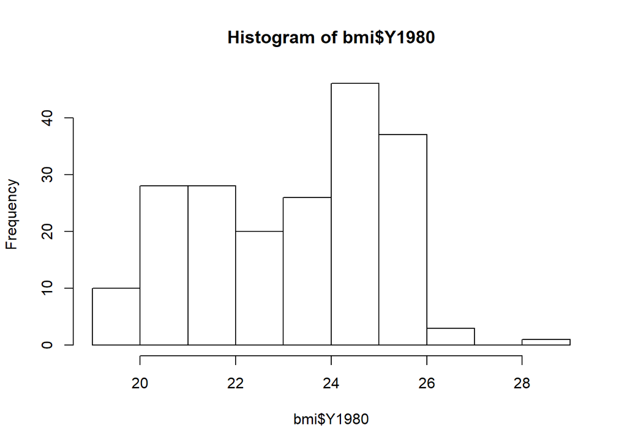

```r
#시각화
hist(bmi$Y1980)
```

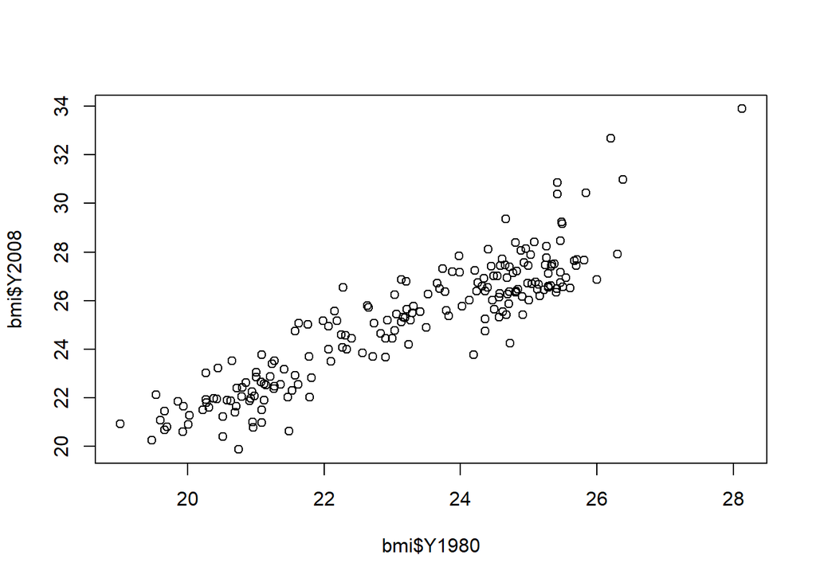

```r
plot(x=bmi$Y1980,y=bmi$Y2008)
```

### Data Clearing

- gather(df, columnname,columnval,columnname 범위) # 넓은 데이터를 좁게
- spread(data, 쪼갤column) #근데 이걸 구분시켜줄 어떤 변수가 있어야함
- separate(df, col, c(변수,변수, …),sep=’-’는 디폴트) 변수를 나눠주는 것
- unite(df,변수이름, col, col)

```r
wide_df <- data.frame(col = c('X', 'Y'), A = c(1,4), B = c(2,5), C = c(3,6))
long_df <- gather(wide_df,my_key, my_val, 2:4)
spread(long_df,my_key,my_val)
```

```
##   col A B C
## 1   X 1 2 3
## 2   Y 4 5 6
```

```r
#exercise01
bmi_long <- gather(bmi, year, bmi_val, 2:30)
#bmi_long
bmi_wide <- spread(bmi_long, year,bmi_val)
#bmi_wide
#exercise02
bmic <- read.csv('C:/Users/user/Documents/github_Rstudio_workspace/Data/bmi_cc.csv', header=TRUE)
head(bmic)
```

```
##              Country_ISO  year  bmi_val
## 1         Afghanistan/AF Y1980 21.48678
## 2             Albania/AL Y1980 25.22533
## 3             Algeria/DZ Y1980 22.25703
## 4             Andorra/AD Y1980 25.66652
## 5              Angola/AO Y1980 20.94876
## 6 Antigua and Barbuda/AG Y1980 23.31424
```

```r
bmic_clean <- separate(bmic,Country_ISO,c('Country','ISO'),sep='/')
#unite(bmic_clean,Country_ISO,Country,ISO, sep='/')
```

### Type Conversion

- class()
- as.logical()
- as.numeric()
- library(‘lubridate’) => ymd, mdy <- date, hms <- time

```r
date <- c('2010-10-01','2010-12-31')
summary(as.Date(date))
```

```
##         Min.      1st Qu.       Median         Mean      3rd Qu.         Max.
## "2010-10-01" "2010-10-23" "2010-11-15" "2010-11-15" "2010-12-08" "2010-12-31"
```

### String Manipulation

- str_trim() :좌우 공백제거
- str_pad(변수, with=숫자, side=‘left’, pad=‘0’) :자리수맞춰주기
- str_detect(vector,‘찾고싶은거’)
- str_replace(vector,‘빼고싶은거’,‘넣고싶은거’)
- tolower() : 소문자
- toupper() : 대문자

```r
#exercise3
students2 <- read.csv('C:/Users/user/Documents/github_Rstudio_workspace/Data/students2.csv',header=TRUE,stringsAsFactors = F)
str(students2)
```

```
## 'data.frame':    395 obs. of  33 variables:
##  $ X          : int  1 2 3 4 5 6 7 8 9 10 ...
##  $ school     : chr  "GP" "GP" "GP" "GP" ...
##  $ sex        : chr  "F" "F" "F" "F" ...
##  $ dob        : chr  "2000-06-05" "1999-11-25" "1998-02-02" "1997-12-20" ...
##  $ address    : chr  "U" "U" "U" "U" ...
##  $ famsize    : chr  "GT3" "GT3" "LE3" "GT3" ...
##  $ Pstatus    : chr  "A" "T" "T" "T" ...
##  $ Medu       : int  4 1 1 4 3 4 2 4 3 3 ...
##  $ Fedu       : int  4 1 1 2 3 3 2 4 2 4 ...
##  $ Mjob       : chr  "at_home" "at_home" "at_home" "health" ...
##  $ Fjob       : chr  "teacher" "other" "other" "services" ...
##  $ reason     : chr  "course" "course" "other" "home" ...
##  $ guardian   : chr  "mother" "father" "mother" "mother" ...
##  $ traveltime : int  2 1 1 1 1 1 1 2 1 1 ...
```

[output cut: 19 more lines]

```r
library('lubridate')
students2$dob <- ymd(students2$dob)
students2$nurse_visit <- ymd_hms(students2$nurse_visit)
str(students2)
```

```
## 'data.frame':    395 obs. of  33 variables:
##  $ X          : int  1 2 3 4 5 6 7 8 9 10 ...
##  $ school     : chr  "GP" "GP" "GP" "GP" ...
##  $ sex        : chr  "F" "F" "F" "F" ...
##  $ dob        : Date, format: "2000-06-05" "1999-11-25" ...
##  $ address    : chr  "U" "U" "U" "U" ...
##  $ famsize    : chr  "GT3" "GT3" "LE3" "GT3" ...
##  $ Pstatus    : chr  "A" "T" "T" "T" ...
##  $ Medu       : int  4 1 1 4 3 4 2 4 3 3 ...
##  $ Fedu       : int  4 1 1 2 3 3 2 4 2 4 ...
##  $ Mjob       : chr  "at_home" "at_home" "at_home" "health" ...
##  $ Fjob       : chr  "teacher" "other" "other" "services" ...
##  $ reason     : chr  "course" "course" "other" "home" ...
##  $ guardian   : chr  "mother" "father" "mother" "mother" ...
##  $ traveltime : int  2 1 1 1 1 1 1 2 1 1 ...
```

[output cut: 19 more lines]

```r
#exercise4
str_detect(students2$dob,'1997')
```

```
##   [1] FALSE FALSE FALSE  TRUE FALSE FALSE  TRUE FALSE FALSE  TRUE FALSE FALSE
##  [13] FALSE  TRUE FALSE FALSE  TRUE FALSE FALSE FALSE FALSE FALSE  TRUE  TRUE
##  [25]  TRUE FALSE FALSE  TRUE FALSE FALSE FALSE FALSE FALSE FALSE  TRUE FALSE
##  [37]  TRUE FALSE FALSE FALSE FALSE  TRUE  TRUE FALSE FALSE FALSE  TRUE  TRUE
##  [49]  TRUE  TRUE  TRUE FALSE FALSE FALSE FALSE FALSE  TRUE  TRUE FALSE FALSE
##  [61] FALSE FALSE FALSE FALSE FALSE FALSE FALSE  TRUE FALSE FALSE  TRUE FALSE
##  [73] FALSE FALSE FALSE FALSE FALSE FALSE FALSE FALSE  TRUE FALSE FALSE  TRUE
##  [85] FALSE FALSE FALSE  TRUE FALSE FALSE  TRUE  TRUE FALSE  TRUE FALSE  TRUE
##  [97]  TRUE FALSE  TRUE  TRUE FALSE FALSE FALSE FALSE FALSE FALSE FALSE FALSE
## [109] FALSE FALSE FALSE FALSE FALSE  TRUE FALSE  TRUE FALSE FALSE FALSE FALSE
## [121]  TRUE  TRUE FALSE FALSE FALSE FALSE  TRUE FALSE FALSE FALSE FALSE  TRUE
## [133] FALSE FALSE FALSE FALSE  TRUE FALSE FALSE FALSE  TRUE FALSE FALSE  TRUE
## [145] FALSE  TRUE FALSE FALSE  TRUE  TRUE FALSE FALSE FALSE  TRUE FALSE FALSE
## [157] FALSE FALSE FALSE FALSE FALSE FALSE  TRUE FALSE  TRUE  TRUE  TRUE FALSE
## [169] FALSE FALSE FALSE  TRUE  TRUE  TRUE FALSE FALSE FALSE FALSE FALSE FALSE
```

[output cut: 18 more lines]

```r
students2$sex <- str_replace(students2$sex,'F','Female')
students2$sex <- str_replace(students2$sex,'M','Male')
head(students2)
```

```
##   X school    sex        dob address famsize Pstatus Medu Fedu     Mjob
## 1 1     GP Female 2000-06-05       U     GT3       A    4    4  at_home
## 2 2     GP Female 1999-11-25       U     GT3       T    1    1  at_home
## 3 3     GP Female 1998-02-02       U     LE3       T    1    1  at_home
## 4 4     GP Female 1997-12-20       U     GT3       T    4    2   health
## 5 5     GP Female 1998-10-04       U     GT3       T    3    3    other
## 6 6     GP   Male 1999-06-16       U     LE3       T    4    3 services
##       Fjob     reason guardian traveltime studytime failures schoolsup famsup
## 1  teacher     course   mother          2         2        0       yes     no
## 2    other     course   father          1         2        0        no    yes
## 3    other      other   mother          1         2        3       yes     no
## 4 services       home   mother          1         3        0        no    yes
## 5    other       home   father          1         2        0        no    yes
## 6    other reputation   mother          1         2        0        no    yes
##   paid activities nursery higher internet romantic famrel freetime goout Dalc
## 1   no         no     yes    yes       no       no      4        3     4    1
## 2   no         no      no    yes      yes       no      5        3     3    1
## 3  yes         no     yes    yes      yes       no      4        3     2    2
## 4  yes        yes     yes    yes      yes      yes      3        2     2    1
## 5  yes         no     yes    yes       no       no      4        3     2    1
## 6  yes        yes     yes    yes      yes       no      5        4     2    1
##   Walc health         nurse_visit absences   Grades
## 1    1      3 2014-04-10 14:59:54        6    5/6/6
## 2    1      3 2015-03-12 14:59:54        4    5/5/6
## 3    3      3 2015-09-21 14:59:54       10   7/8/10
## 4    1      5 2015-09-03 14:59:54        2 15/14/15
## 5    2      5 2015-04-07 14:59:54        4  6/10/10
## 6    2      5 2013-11-15 14:59:54       10 15/15/15
```

### NA Handling

- is.na(df) : TRUE FALSE로 결과치 나옴
- any(is.na(df)) : 결측치가 있냐
- sum(is.na(df)) : 개수새기
- complete.cases(df) : 결측치가 하나도 없는 행=TRUE
- df[complete.cases(df),] : na가 없는 행
- na.omit(df) : na행 다 날려버리기기

```r
students3 <- read.csv('C:/Users/user/Documents/github_Rstudio_workspace/Data/students3.csv',header=TRUE,stringsAsFactors = F)
str(students3)
```

```
## 'data.frame':    395 obs. of  31 variables:
##  $ school    : chr  "GP" "GP" "GP" "GP" ...
##  $ sex       : chr  "F" "F" "F" "F" ...
##  $ age       : int  18 17 15 15 16 16 16 17 38 15 ...
##  $ address   : chr  "U" "U" "U" "U" ...
##  $ famsize   : chr  "GT3" "GT3" "LE3" "GT3" ...
##  $ Pstatus   : chr  "A" "T" "T" "T" ...
##  $ Medu      : int  4 1 1 4 3 4 2 4 3 3 ...
##  $ Fedu      : int  4 1 1 2 3 3 2 4 2 4 ...
##  $ Mjob      : chr  "at_home" "at_home" "at_home" "health" ...
##  $ Fjob      : chr  "teacher" "other" "other" "services" ...
##  $ reason    : chr  "course" "course" "other" "home" ...
##  $ guardian  : chr  "mother" "father" "mother" "mother" ...
##  $ traveltime: int  2 1 1 1 1 1 1 2 1 1 ...
##  $ studytime : int  2 2 2 3 2 2 2 2 2 2 ...
```

[output cut: 17 more lines]

```r
attach(students3)
summary(age)
```

```
##    Min. 1st Qu.  Median    Mean 3rd Qu.    Max.
##   15.00   16.00   17.00   16.75   18.00   38.00
```

```r
summary(absences)
```

```
##    Min. 1st Qu.  Median    Mean 3rd Qu.    Max.
##  -1.000   0.000   4.000   5.691   8.000  75.000
```

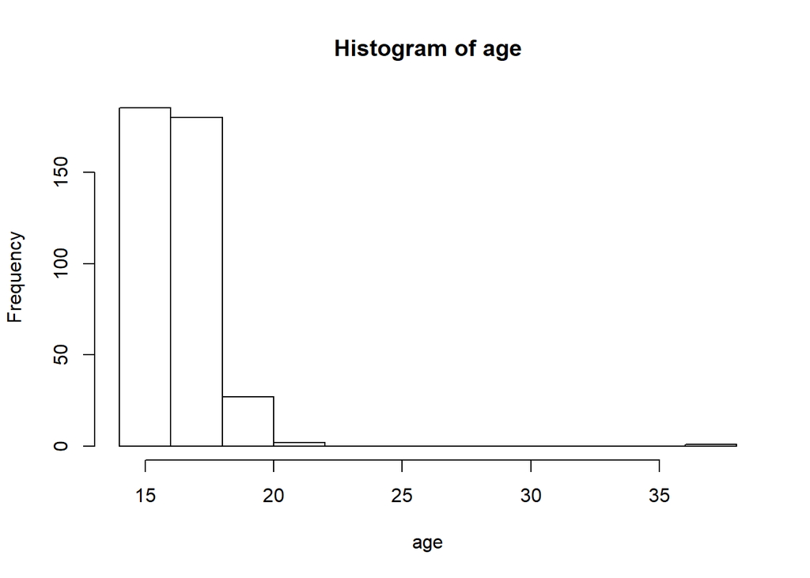

```r
hist(age)
```

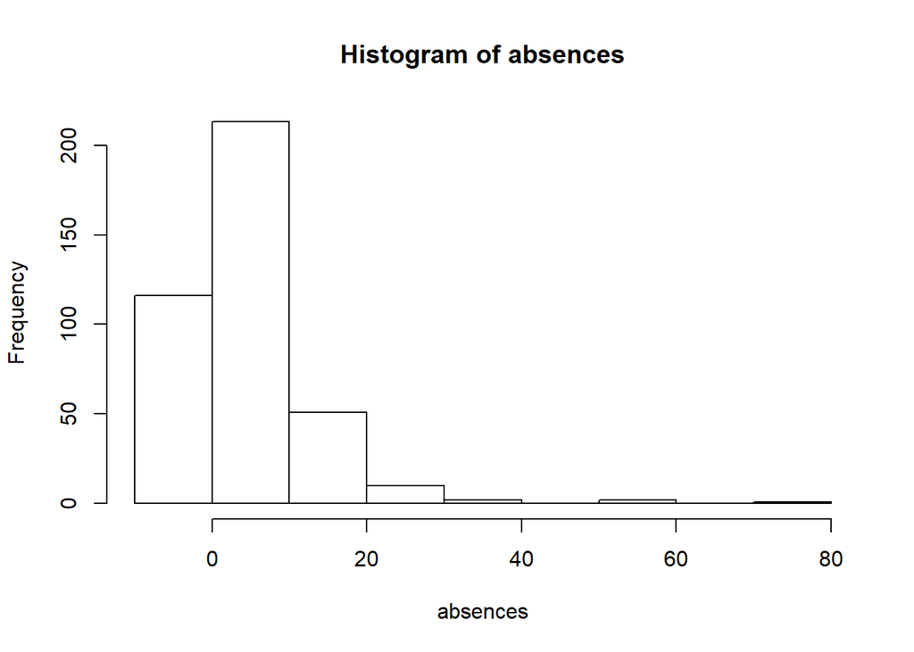

```r
hist(absences)
```

```r
students3$absences <- str_replace(absences,'-1','NA')
#students3
str_detect(absences,'NA')
```

```
##   [1] FALSE FALSE FALSE FALSE FALSE FALSE FALSE FALSE FALSE FALSE FALSE FALSE
##  [13] FALSE FALSE FALSE FALSE FALSE FALSE FALSE FALSE FALSE FALSE FALSE FALSE
##  [25] FALSE FALSE FALSE FALSE FALSE FALSE FALSE FALSE FALSE FALSE FALSE FALSE
##  [37] FALSE FALSE FALSE FALSE FALSE FALSE FALSE FALSE FALSE FALSE FALSE FALSE
##  [49] FALSE FALSE FALSE FALSE FALSE FALSE FALSE FALSE FALSE FALSE FALSE FALSE
##  [61] FALSE FALSE FALSE FALSE FALSE FALSE FALSE FALSE FALSE FALSE FALSE FALSE
##  [73] FALSE FALSE FALSE FALSE FALSE FALSE FALSE FALSE FALSE FALSE FALSE FALSE
##  [85] FALSE FALSE FALSE FALSE FALSE FALSE FALSE FALSE FALSE FALSE FALSE FALSE
##  [97] FALSE FALSE FALSE FALSE FALSE FALSE FALSE FALSE FALSE FALSE FALSE FALSE
## [109] FALSE FALSE FALSE FALSE FALSE FALSE FALSE FALSE FALSE FALSE FALSE FALSE
## [121] FALSE FALSE FALSE FALSE FALSE FALSE FALSE FALSE FALSE FALSE FALSE FALSE
## [133] FALSE FALSE FALSE FALSE FALSE FALSE FALSE FALSE FALSE FALSE FALSE FALSE
## [145] FALSE FALSE FALSE FALSE FALSE FALSE FALSE FALSE FALSE FALSE FALSE FALSE
## [157] FALSE FALSE FALSE FALSE FALSE FALSE FALSE FALSE FALSE FALSE FALSE FALSE
## [169] FALSE FALSE FALSE FALSE FALSE FALSE FALSE FALSE FALSE FALSE FALSE FALSE
```

[output cut: 18 more lines]

## 데이터과학 9주차 강의노트

### 명목형 변수로 model만들기

```r
#Data load
load(url('https://github.com/hbchoi/SampleData/raw/master/adult.RData'))
set.seed(2020)
#train, test set 설정
n_sample <- nrow(adult)
rgroup <- runif(n_sample)#균등분포에서의 난수생성
adult.train <- subset(adult,rgroup<=0.8)
adult.test <- subset(adult, rgroup>0.8)
#table 쓰는 법
table(adult.train$income_mt_50k)#명목형 변수 빈도를 보여줌
```

```
##
## FALSE  TRUE
## 19740  6300
```

```r
prop.table(table(adult.train$income_mt_50k))#소수점 비율로 보여줌
```

```
##
##     FALSE      TRUE
## 0.7580645 0.2419355
```

```r
# 모델 전 처리
tble <- table(adult.train$occupation,adult.train$income_mt_50k)#row,column
sv_model_job <- prop.table(tble,margin = 1)[,2] # 뒤에 [,] 붙여서 원하는 행 열 뽑아낼 수 있음
adult.train$est_prob <- sv_model_job[adult.train$occupation]
#간단한 모델 만들기
threshold <- 0.4
adult.train$prediction <- adult.train$est_prob>threshold
head(adult.train[,c('occupation','est_prob','prediction','income_mt_50k')],10)
```

```
##            occupation   est_prob prediction income_mt_50k
## 1        Adm-clerical 0.13949580      FALSE         FALSE
## 2     Exec-managerial 0.48021911       TRUE         FALSE
## 3   Handlers-cleaners 0.06654344      FALSE         FALSE
## 4   Handlers-cleaners 0.06654344      FALSE         FALSE
## 5      Prof-specialty 0.44879518       TRUE         FALSE
## 6     Exec-managerial 0.48021911       TRUE         FALSE
## 7       Other-service 0.04057641      FALSE         FALSE
## 8     Exec-managerial 0.48021911       TRUE          TRUE
## 9      Prof-specialty 0.44879518       TRUE          TRUE
## 10    Exec-managerial 0.48021911       TRUE          TRUE
```

```r
#얼마나 맞췄는지 확인
conf.table <- table(pred=adult.train$prediction, actual=adult.train$income_mt_50k)
conf.table
```

```
##        actual
## pred    FALSE  TRUE
##   FALSE 16202  3232
##   TRUE   3538  3068
```

```r
accuracy <- sum(diag(conf.table))/sum(conf.table)
accuracy
```

```
## [1] 0.7400154
```

```r
#이후에는 train set에서 같은 기준을 적용했을 때 어느 정도 나오는지를 확인해야 함
```

```r
# 모델 전 처리
tble <- table(adult.train$education,adult.train$income_mt_50k)
sv_model_job <- prop.table(tble,margin = 1)[,2]
adult.train$est_prob <- sv_model_job[adult.train$education]
#역치0.5
threshold <- 0.5
adult.train$prediction <- adult.train$est_prob>threshold
conf.table <- table(pred <- adult.train$prediction,actual <- adult.train$income_mt_50k)
accuracy <- sum(diag(conf.table))/sum(conf.table)
accuracy
```

```
## [1] 0.7788018
```

```r
recall <-  sum(conf.table[2,2])/sum(conf.table[,2])
recall
```

```
## [1] 0.2152381
```

```r
precision <- sum(conf.table[2,2])/sum(conf.table[2,])
precision
```

```
## [1] 0.6243094
```

```r
#역치0.6
threshold <- 0.6
adult.train$prediction <- adult.train$est_prob>threshold
conf.table <- table(pred <- adult.train$prediction,actual <- adult.train$income_mt_50k)
accuracy <- sum(diag(conf.table))/sum(conf.table)
accuracy
```

```
## [1] 0.7726959
```

```r
recall <-  sum(conf.table[2,2])/sum(conf.table[,2])
recall
```

```
## [1] 0.09380952
```

```r
precision <- sum(conf.table[2,2])/sum(conf.table[2,])
precision
```

```
## [1] 0.7378277
```

```r
#test set 기준으로 얼마나 맞았는지 확인
tble <- table(adult.test$education,adult.test$income_mt_50k)
sv_model_job <- prop.table(tble,margin = 1)[,2]
adult.test$est_prob <- sv_model_job[adult.test$education]
threshold <- 0.5
adult.test$prediction <- adult.test$est_prob>threshold
conf.table <- table(actual <- adult.test$prediction, actual <- adult.test$income_mt_50k)
accuracy <- sum(diag(conf.table))/sum(conf.table)
accuracy
```

```
## [1] 0.782702
```

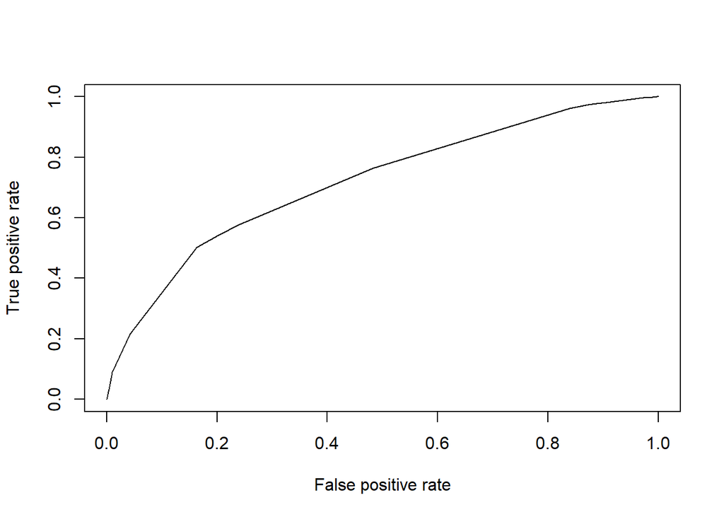

```r
#AUC curve Visualization
plot(performance(prediction(adult.test$est_prob,adult.test$income_mt_50k),'tpr','fpr')) #앞변수로 뒷변수를 얼마나 잘 예측하 수 있느냐
```

```r
adult.train$age_group <- cut(adult.train$age, breaks=c(0,20,30,40,50,60, Inf),labels=c('under20','20s','30s','40s','50s','over60'),
                             right = F)
tble <- table(adult.train$age_group,adult.train$income_mt_50k)
sv_model_age <- prop.table(tble,margin=1)[,2]
adult.train$est_prob <- sv_model_age[adult.train$age_group]
threshold <- 0.3
adult.train$predictoni <- adult.train$est_prob >threshold
#accuracy 사용자 정의 함수
get_accuracy <- function(pred,actual){
  tble <- table(pred,actual)
  return(round(sum(diag(tble))/sum(tble),3))
}
get_accuracy(adult.train$prediction,adult.train$income_mt_50k)
```

```
## [1] 0.773
```

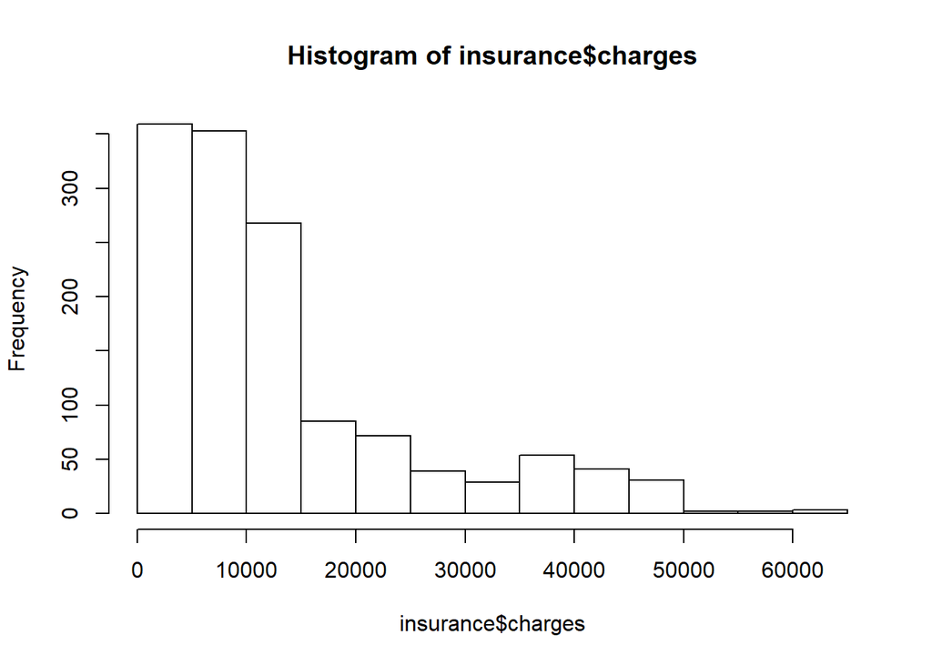

```r
#Data load
load(url('https://github.com/hbchoi/SampleData/raw/master/insurance.RData'))
#Data Browse
hist(insurance$charges)
```

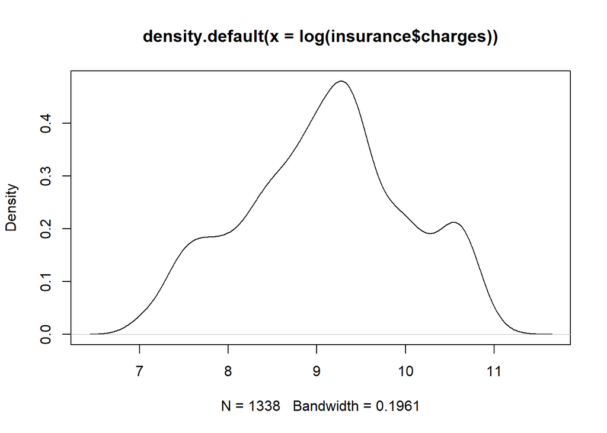

```r
plot(density(log(insurance$charges)))#log를 씌우면 편포가 정규모양으로 바뀔 수 있음
```

```r
insurance$logcharges <- log10(insurance$charges)
#test, training set
set.seed(2020)
n_sample <- nrow(insurance)
rgroup <- runif(n_sample)
train <- subset(insurance,rgroup<=0.8)
test <- subset(insurance,rgroup>0.8)
#model 전처리
sv_reg_smoker <- tapply(train$logcharges, train$smoker,mean)
train$pred <- sv_reg_smoker[train$smoker]
train$error <- train$logcharges-train$pred
msetrain <- mean(train$error**2)
msetrain
```

```
## [1] 0.09060696
```

```r
sqrt(msetrain)
```

```
## [1] 0.3010099
```

## 데이터과학 11주차 강의노트

### Decision Tree

- 대출클럽같은 곳에 많이 쓰임
- Entropy = 혼잡도 : 데이터가 비슷하게 섞여있으면 높고, 한가지 종류만 있으면 낮음
- {sigma_(k- > 분할개수) -p_k*logp_k} {p_k=전체중에 해당 부분}
- root= 전체, split=나눈거 , n=샘플수, loss=rapid가 아닌 수(deafult, rapid)
- 해석방법: root 전체개수 나눈개수 구하고자하는것(x) (1-p(x),p(x))
- prepruning은 미리 복잡함의 정도를 정해두는 것임 [maxdepth ,minimumsplit (쪼개진 샘플 수가 일정 수준 이하로 내려가지 않게 하는 것)]
- postpruning은 다 만들고 어느 선에서 정리하는 것 [plotcp(model)쓰면 model의 에러값과 cp의 값 plotd이 뜨는데 여기서 cp값 보고 결정]
- predict(model,data,type=‘class’ 등등)
- cp=0을 둔다는 것은 제한없이 쭉 끝까지 한다는 뜻

```r
load(url('https://github.com/hbchoi/SampleData/blob/master/dtree_data.RData?raw=true'))
str(loans)
```

```
## 'data.frame':    11312 obs. of  14 variables:
##  $ loan_amount       : Factor w/ 3 levels "HIGH","LOW","MEDIUM": 2 2 2 3 2 3 3 2 1 3 ...
##  $ emp_length        : Factor w/ 5 levels "< 2 years","10+ years",..: 2 1 4 3 1 1 3 2 2 1 ...
##  $ home_ownership    : Factor w/ 4 levels "MORTGAGE","OTHER",..: 4 4 4 3 4 4 4 1 4 4 ...
##  $ income            : Factor w/ 3 levels "HIGH","LOW","MEDIUM": 2 2 3 3 2 2 1 1 1 3 ...
##  $ loan_purpose      : Factor w/ 14 levels "car","credit_card",..: 2 1 1 12 10 3 10 7 3 7 ...
##  $ debt_to_income    : Factor w/ 3 levels "AVERAGE","HIGH",..: 2 3 3 3 1 1 3 1 1 3 ...
##  $ credit_score      : Factor w/ 3 levels "AVERAGE","HIGH",..: 1 1 3 1 1 1 1 2 1 1 ...
##  $ recent_inquiry    : Factor w/ 2 levels "NO","YES": 2 2 2 2 1 2 2 1 1 2 ...
##  $ delinquent        : Factor w/ 3 levels "IN PAST 2 YEARS",..: 3 3 3 3 3 3 3 3 3 3 ...
##  $ credit_accounts   : Factor w/ 3 levels "AVERAGE","FEW",..: 2 2 2 1 2 2 3 3 1 1 ...
##  $ bad_public_record : Factor w/ 2 levels "NO","YES": 1 1 1 1 1 1 1 1 1 1 ...
##  $ credit_utilization: Factor w/ 3 levels "HIGH","LOW","MEDIUM": 1 2 1 3 3 1 3 2 1 3 ...
##  $ past_bankrupt     : Factor w/ 2 levels "NO","YES": 1 1 1 1 1 1 1 1 1 1 ...
##  $ outcome           : Factor w/ 2 levels "default","rapid": 2 1 2 1 1 1 1 2 1 1 ...
```

```r
loan_model <- rpart(outcome~loan_amount+credit_score,data=loans,method='class',
                    control=rpart.control(cp=0))
loan_model
```

```
## n= 11312
##
## node), split, n, loss, yval, (yprob)
##       * denotes terminal node
##
##  1) root 11312 5654 rapid (0.4998232 0.5001768)
##    2) credit_score=AVERAGE,LOW 9490 4437 default (0.5324552 0.4675448)
##      4) credit_score=LOW 1667  631 default (0.6214757 0.3785243) *
##      5) credit_score=AVERAGE 7823 3806 default (0.5134859 0.4865141)
##       10) loan_amount=HIGH 2472 1079 default (0.5635113 0.4364887) *
##       11) loan_amount=LOW,MEDIUM 5351 2624 rapid (0.4903756 0.5096244)
##         22) loan_amount=LOW 1810  874 default (0.5171271 0.4828729) *
##         23) loan_amount=MEDIUM 3541 1688 rapid (0.4767015 0.5232985) *
##    3) credit_score=HIGH 1822  601 rapid (0.3298573 0.6701427) *
```

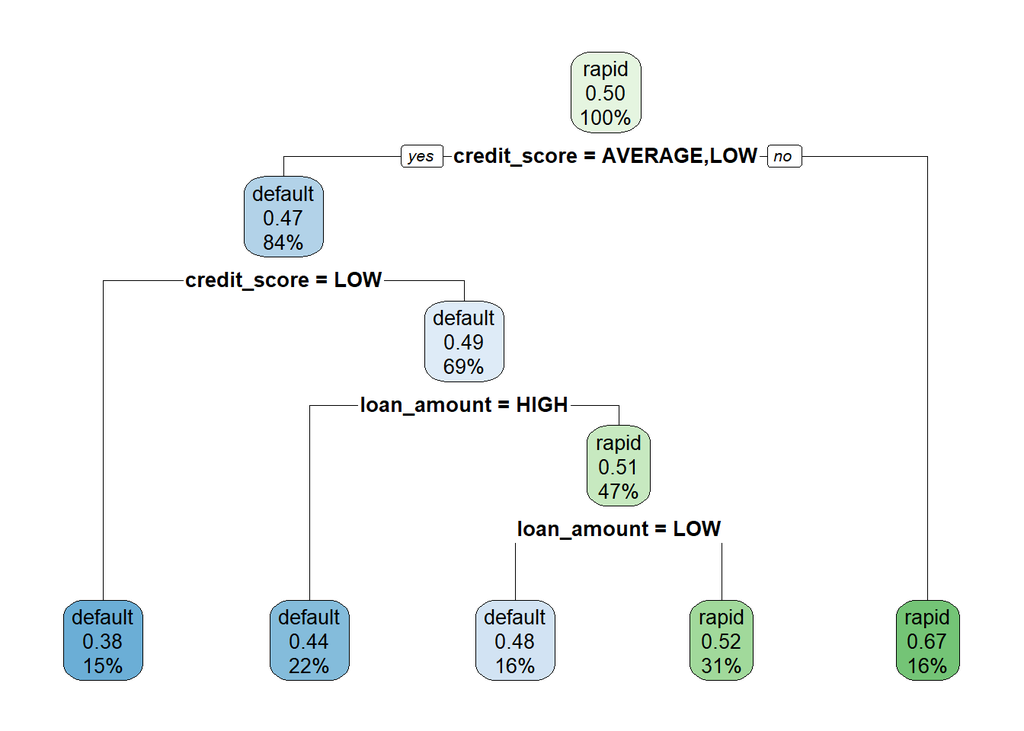

```r
rpart.plot(loan_model)
```

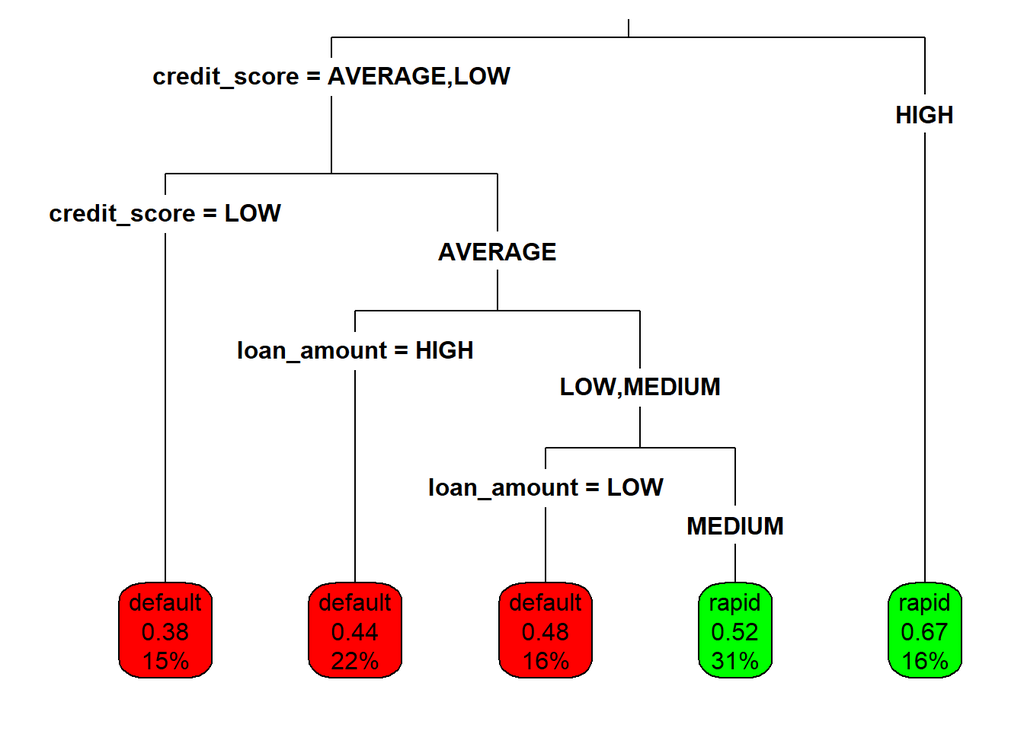

```r
rpart.plot(loan_model, type=3, box.palette=c('red','green'),fallen.leaves= TRUE)
```

```r
#Prepruning maxdepth로 정하기
loan_model <- rpart(outcome ~ ., data=loans, method='class',
                    control=rpart.control(cp=0,maxdepth=6))
#Prepruning minimumsplit으로 정하기
loan_model <- rpart(outcome ~ ., data=loans, method='class',
                    control=rpart.control(cp=0,minsplit = 500))
#Postpruning
loan_model_pruned <- prune(loan_model,cp=0.0014) # 이런 식으로 결정
```

###K Nearest Neighbors * pred <- knn(train, test, cl, k = 1, l = 0, prob = FALSE, use.all = TRUE) - train : 훈련 데이터셋 (matrix or data frame) - test : 테스트 데이터셋 (matrix or data frame) - cl: 훈련 데이터셋의 그룹(class) 정보 (factor) - k : 이웃(neighbour)의 수 - l : 명확한 결정을 위한 최소 유효 수, 그렇지 않은 경우 의심 - prob: 만약 이것이 트루라면, 프로브 속성에서 당첨된 비율을 반환한다. - use.all: 만약 트루라면, K번째의 최대치에 해당하는 모든 거리가 포함된다. 거짓이면 k의 이웃 포인트를 정확히 사용하기 위해 K번째와 같은 거리를 무작위로 선택한다. * 유클리디안 거리를 구하기 위해 표준화를 시켜야 함

```r
wbcd <- read.csv("https://github.com/hbchoi/SampleData/raw/master/wisc_bc_data.csv",stringsAsFactors=F)
wbcd <- wbcd[,-1]
wbcd$diagnosis <- ifelse(wbcd$diagnosis=='B',' Benign','Malignant')
table(wbcd$diagnosis)
```

```
##
##    Benign Malignant
##       357       212
```

```r
#min-max normalization for Euclidean Distance
minmax_norm <- function(x){
  (x-min(x))/(max(x)-min(x))
}
wbcd_norm <- sapply(wbcd[-1], minmax_norm)
summary(wbcd)
```

```
##   diagnosis          radius_mean      texture_mean   perimeter_mean
##  Length:569         Min.   : 6.981   Min.   : 9.71   Min.   : 43.79
##  Class :character   1st Qu.:11.700   1st Qu.:16.17   1st Qu.: 75.17
##  Mode  :character   Median :13.370   Median :18.84   Median : 86.24
##                     Mean   :14.127   Mean   :19.29   Mean   : 91.97
##                     3rd Qu.:15.780   3rd Qu.:21.80   3rd Qu.:104.10
##                     Max.   :28.110   Max.   :39.28   Max.   :188.50
##    area_mean      smoothness_mean   compactness_mean  concavity_mean
##  Min.   : 143.5   Min.   :0.05263   Min.   :0.01938   Min.   :0.00000
##  1st Qu.: 420.3   1st Qu.:0.08637   1st Qu.:0.06492   1st Qu.:0.02956
##  Median : 551.1   Median :0.09587   Median :0.09263   Median :0.06154
##  Mean   : 654.9   Mean   :0.09636   Mean   :0.10434   Mean   :0.08880
##  3rd Qu.: 782.7   3rd Qu.:0.10530   3rd Qu.:0.13040   3rd Qu.:0.13070
##  Max.   :2501.0   Max.   :0.16340   Max.   :0.34540   Max.   :0.42680
##   points_mean      symmetry_mean    dimension_mean      radius_se
##  Min.   :0.00000   Min.   :0.1060   Min.   :0.04996   Min.   :0.1115
##  1st Qu.:0.02031   1st Qu.:0.1619   1st Qu.:0.05770   1st Qu.:0.2324
##  Median :0.03350   Median :0.1792   Median :0.06154   Median :0.3242
##  Mean   :0.04892   Mean   :0.1812   Mean   :0.06280   Mean   :0.4052
##  3rd Qu.:0.07400   3rd Qu.:0.1957   3rd Qu.:0.06612   3rd Qu.:0.4789
##  Max.   :0.20120   Max.   :0.3040   Max.   :0.09744   Max.   :2.8730
##    texture_se      perimeter_se       area_se        smoothness_se
##  Min.   :0.3602   Min.   : 0.757   Min.   :  6.802   Min.   :0.001713
##  1st Qu.:0.8339   1st Qu.: 1.606   1st Qu.: 17.850   1st Qu.:0.005169
##  Median :1.1080   Median : 2.287   Median : 24.530   Median :0.006380
##  Mean   :1.2169   Mean   : 2.866   Mean   : 40.337   Mean   :0.007041
##  3rd Qu.:1.4740   3rd Qu.: 3.357   3rd Qu.: 45.190   3rd Qu.:0.008146
##  Max.   :4.8850   Max.   :21.980   Max.   :542.200   Max.   :0.031130
##  compactness_se      concavity_se       points_se         symmetry_se
##  Min.   :0.002252   Min.   :0.00000   Min.   :0.000000   Min.   :0.007882
##  1st Qu.:0.013080   1st Qu.:0.01509   1st Qu.:0.007638   1st Qu.:0.015160
##  Median :0.020450   Median :0.02589   Median :0.010930   Median :0.018730
##  Mean   :0.025478   Mean   :0.03189   Mean   :0.011796   Mean   :0.020542
##  3rd Qu.:0.032450   3rd Qu.:0.04205   3rd Qu.:0.014710   3rd Qu.:0.023480
##  Max.   :0.135400   Max.   :0.39600   Max.   :0.052790   Max.   :0.078950
##   dimension_se        radius_worst   texture_worst   perimeter_worst
##  Min.   :0.0008948   Min.   : 7.93   Min.   :12.02   Min.   : 50.41
##  1st Qu.:0.0022480   1st Qu.:13.01   1st Qu.:21.08   1st Qu.: 84.11
##  Median :0.0031870   Median :14.97   Median :25.41   Median : 97.66
##  Mean   :0.0037949   Mean   :16.27   Mean   :25.68   Mean   :107.26
##  3rd Qu.:0.0045580   3rd Qu.:18.79   3rd Qu.:29.72   3rd Qu.:125.40
##  Max.   :0.0298400   Max.   :36.04   Max.   :49.54   Max.   :251.20
##    area_worst     smoothness_worst  compactness_worst concavity_worst
##  Min.   : 185.2   Min.   :0.07117   Min.   :0.02729   Min.   :0.0000
##  1st Qu.: 515.3   1st Qu.:0.11660   1st Qu.:0.14720   1st Qu.:0.1145
##  Median : 686.5   Median :0.13130   Median :0.21190   Median :0.2267
##  Mean   : 880.6   Mean   :0.13237   Mean   :0.25427   Mean   :0.2722
##  3rd Qu.:1084.0   3rd Qu.:0.14600   3rd Qu.:0.33910   3rd Qu.:0.3829
##  Max.   :4254.0   Max.   :0.22260   Max.   :1.05800   Max.   :1.2520
##   points_worst     symmetry_worst   dimension_worst
##  Min.   :0.00000   Min.   :0.1565   Min.   :0.05504
##  1st Qu.:0.06493   1st Qu.:0.2504   1st Qu.:0.07146
##  Median :0.09993   Median :0.2822   Median :0.08004
##  Mean   :0.11461   Mean   :0.2901   Mean   :0.08395
##  3rd Qu.:0.16140   3rd Qu.:0.3179   3rd Qu.:0.09208
##  Max.   :0.29100   Max.   :0.6638   Max.   :0.20750
```

```r
summary(wbcd_norm)
```

```
##   radius_mean      texture_mean    perimeter_mean     area_mean
##  Min.   :0.0000   Min.   :0.0000   Min.   :0.0000   Min.   :0.0000
##  1st Qu.:0.2233   1st Qu.:0.2185   1st Qu.:0.2168   1st Qu.:0.1174
##  Median :0.3024   Median :0.3088   Median :0.2933   Median :0.1729
##  Mean   :0.3382   Mean   :0.3240   Mean   :0.3329   Mean   :0.2169
##  3rd Qu.:0.4164   3rd Qu.:0.4089   3rd Qu.:0.4168   3rd Qu.:0.2711
##  Max.   :1.0000   Max.   :1.0000   Max.   :1.0000   Max.   :1.0000
##  smoothness_mean  compactness_mean concavity_mean     points_mean
##  Min.   :0.0000   Min.   :0.0000   Min.   :0.00000   Min.   :0.0000
##  1st Qu.:0.3046   1st Qu.:0.1397   1st Qu.:0.06926   1st Qu.:0.1009
##  Median :0.3904   Median :0.2247   Median :0.14419   Median :0.1665
##  Mean   :0.3948   Mean   :0.2606   Mean   :0.20806   Mean   :0.2431
##  3rd Qu.:0.4755   3rd Qu.:0.3405   3rd Qu.:0.30623   3rd Qu.:0.3678
##  Max.   :1.0000   Max.   :1.0000   Max.   :1.00000   Max.   :1.0000
##  symmetry_mean    dimension_mean     radius_se         texture_se
##  Min.   :0.0000   Min.   :0.0000   Min.   :0.00000   Min.   :0.0000
##  1st Qu.:0.2823   1st Qu.:0.1630   1st Qu.:0.04378   1st Qu.:0.1047
##  Median :0.3697   Median :0.2439   Median :0.07702   Median :0.1653
##  Mean   :0.3796   Mean   :0.2704   Mean   :0.10635   Mean   :0.1893
##  3rd Qu.:0.4530   3rd Qu.:0.3404   3rd Qu.:0.13304   3rd Qu.:0.2462
##  Max.   :1.0000   Max.   :1.0000   Max.   :1.00000   Max.   :1.0000
##   perimeter_se        area_se        smoothness_se    compactness_se
##  Min.   :0.00000   Min.   :0.00000   Min.   :0.0000   Min.   :0.00000
##  1st Qu.:0.04000   1st Qu.:0.02064   1st Qu.:0.1175   1st Qu.:0.08132
##  Median :0.07209   Median :0.03311   Median :0.1586   Median :0.13667
##  Mean   :0.09938   Mean   :0.06264   Mean   :0.1811   Mean   :0.17444
##  3rd Qu.:0.12251   3rd Qu.:0.07170   3rd Qu.:0.2187   3rd Qu.:0.22680
##  Max.   :1.00000   Max.   :1.00000   Max.   :1.0000   Max.   :1.00000
##   concavity_se       points_se       symmetry_se      dimension_se
##  Min.   :0.00000   Min.   :0.0000   Min.   :0.0000   Min.   :0.00000
##  1st Qu.:0.03811   1st Qu.:0.1447   1st Qu.:0.1024   1st Qu.:0.04675
##  Median :0.06538   Median :0.2070   Median :0.1526   Median :0.07919
##  Mean   :0.08054   Mean   :0.2235   Mean   :0.1781   Mean   :0.10019
##  3rd Qu.:0.10619   3rd Qu.:0.2787   3rd Qu.:0.2195   3rd Qu.:0.12656
##  Max.   :1.00000   Max.   :1.0000   Max.   :1.0000   Max.   :1.00000
##   radius_worst    texture_worst    perimeter_worst    area_worst
##  Min.   :0.0000   Min.   :0.0000   Min.   :0.0000   Min.   :0.00000
##  1st Qu.:0.1807   1st Qu.:0.2415   1st Qu.:0.1678   1st Qu.:0.08113
##  Median :0.2504   Median :0.3569   Median :0.2353   Median :0.12321
##  Mean   :0.2967   Mean   :0.3640   Mean   :0.2831   Mean   :0.17091
##  3rd Qu.:0.3863   3rd Qu.:0.4717   3rd Qu.:0.3735   3rd Qu.:0.22090
##  Max.   :1.0000   Max.   :1.0000   Max.   :1.0000   Max.   :1.00000
##  smoothness_worst compactness_worst concavity_worst    points_worst
##  Min.   :0.0000   Min.   :0.0000    Min.   :0.00000   Min.   :0.0000
##  1st Qu.:0.3000   1st Qu.:0.1163    1st Qu.:0.09145   1st Qu.:0.2231
##  Median :0.3971   Median :0.1791    Median :0.18107   Median :0.3434
##  Mean   :0.4041   Mean   :0.2202    Mean   :0.21740   Mean   :0.3938
##  3rd Qu.:0.4942   3rd Qu.:0.3025    3rd Qu.:0.30583   3rd Qu.:0.5546
##  Max.   :1.0000   Max.   :1.0000    Max.   :1.00000   Max.   :1.0000
##  symmetry_worst   dimension_worst
##  Min.   :0.0000   Min.   :0.0000
##  1st Qu.:0.1851   1st Qu.:0.1077
##  Median :0.2478   Median :0.1640
##  Mean   :0.2633   Mean   :0.1896
##  3rd Qu.:0.3182   3rd Qu.:0.2429
##  Max.   :1.0000   Max.   :1.0000
```

```r
#train test
wbcd_train <- wbcd_norm[1:469,]
wbcd_test <- wbcd_norm[470:569,]
wbcd_train_label <- wbcd[1:469,1]
wbcd_test_label <- wbcd[470:569,1]

# k개수는 총 행 개수의 루트로 구했음
sqrt(nrow(wbcd_train))
```

```
## [1] 21.65641
```

```r
wbcd_test_pred <- knn(train=wbcd_train,test=wbcd_test,cl=wbcd_train_label,k=21)
#accuracy
mean(wbcd_test_label==wbcd_test_pred)
```

```
## [1] 0.98
```

```r
#confusion matrix
cmat <- table(wbcd_test_label,wbcd_test_pred)
cmat
```

```
##                wbcd_test_pred
## wbcd_test_label  Benign Malignant
##        Benign        61         0
##       Malignant       2        37
```

```r
precision <- cmat[2,2]/sum(cmat[,2])
recall <- cmat[2,2]/sum(cmat[2,])
#암인사람 주변이 암인사람 비율, 암이 아닌사람 주위 암이 아닌사람 비율
wbcd_test_pred <- knn(train=wbcd_train,test=wbcd_test,cl=wbcd_train_label,k=21,prob=TRUE)
head(attributes(wbcd_test_pred)$prob)
```

```
## [1] 1.000000 0.952381 0.952381 0.952381 1.000000 1.000000
```

```r
head(wbcd_test_pred)
```

```
## [1]  Benign    Benign    Benign    Benign   Malignant  Benign
## Levels:  Benign Malignant
```

```r
wbcd_test_pred_prob <-  ifelse(wbcd_test_pred == 'M', attributes(wbcd_test_pred)$prob, 1-attributes(wbcd_test_pred)$prob)
head(wbcd_test_pred_prob)
```

```
## [1] 0.00000000 0.04761905 0.04761905 0.04761905 0.00000000 0.00000000
```

###시각화 AUC

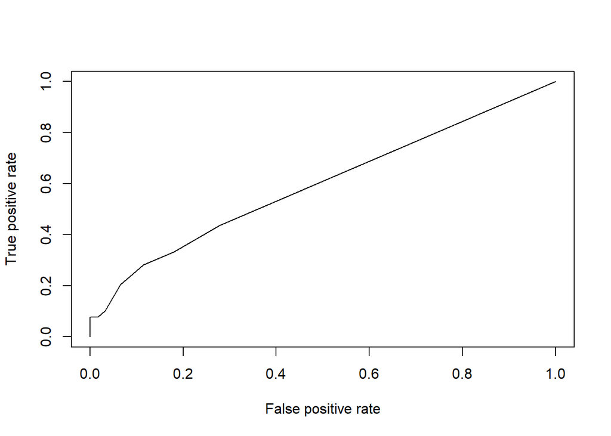

```r
library('ROCR')
plot(performance(prediction(wbcd_test_pred_prob,wbcd_test_label=='Malignant'),'tpr','fpr'))
```

```r
calAUC <- function(predCol,targetCol){
  perf <- performance(prediction(predCol,targetCol),'auc')
  as.numeric(perf@y.values)
}

calAUC(wbcd_test_pred_prob,wbcd_test_label=='Malignant')
```

```
## [1] 0.5956284
```

```r
performance(prediction(wbcd_test_pred_prob,wbcd_test_label=='Malignant'),'auc')
```

```
## An object of class "performance"
## Slot "x.name":
## [1] "None"
##
## Slot "y.name":
## [1] "Area under the ROC curve"
##
## Slot "alpha.name":
## [1] "none"
##
## Slot "x.values":
## list()
##
## Slot "y.values":
## [[1]]
## [1] 0.5956284
##
##
## Slot "alpha.values":
## list()
```

```r
#adjusting threshold
threshold <- 0.1
wbcd_test_pred_new <- ifelse(wbcd_test_pred_prob > threshold, 'Malignant','Benign')
cmat <- table(wbcd_test_label, wbcd_test_pred_new)

#accuracy
mean(wbcd_test_label == wbcd_test_pred_new)
```

```
## [1] 0.11
```

```r
precision <- cmat[2,2]/sum(cmat[,2])
recall <- cmat[2,2]/sum(cmat[2,])
precision
```

```
## [1] 0.6111111
```

```r
recall
```

```
## [1] 0.2820513
```

###더미변수 * one hot encoding * library(caret) * predict(dummyVars(~cbwd,data=data1),data1)

## 데이터과학 13주차 강의노트

###linear model * model <- lm(outcome~independent,data=train) * prediction <- predict(model,test) * 명목형 변수들은 자동으로 더미 변환이되어 계산되는데, #factor개수 -1 로 진행됨 (000 100 010 001 이렇게) * 명목형변수 level 2인 경우 알파벳 순으로 먼저 오는게 reference 값

```r
#data load
load(url('https://github.com/hbchoi/SampleData/raw/master/insurance.RData'))
str(insurance)
```

```
## 'data.frame':    1338 obs. of  7 variables:
##  $ age     : int  19 18 28 33 32 31 46 37 37 60 ...
##  $ sex     : Factor w/ 2 levels "female","male": 1 2 2 2 2 1 1 1 2 1 ...
##  $ bmi     : num  27.9 33.8 33 22.7 28.9 ...
##  $ children: int  0 1 3 0 0 0 1 3 2 0 ...
##  $ smoker  : Factor w/ 2 levels "no","yes": 2 1 1 1 1 1 1 1 1 1 ...
##  $ region  : Factor w/ 4 levels "northeast","northwest",..: 4 3 3 2 2 3 3 2 1 2 ...
##  $ charges : num  16885 1726 4449 21984 3867 ...
```

```r
summary(insurance)
```

```
##       age            sex           bmi           children     smoker
##  Min.   :18.00   female:662   Min.   :15.96   Min.   :0.000   no :1064
##  1st Qu.:27.00   male  :676   1st Qu.:26.30   1st Qu.:0.000   yes: 274
##  Median :39.00                Median :30.40   Median :1.000
##  Mean   :39.21                Mean   :30.66   Mean   :1.095
##  3rd Qu.:51.00                3rd Qu.:34.69   3rd Qu.:2.000
##  Max.   :64.00                Max.   :53.13   Max.   :5.000
##        region       charges
##  northeast:324   Min.   : 1122
##  northwest:325   1st Qu.: 4740
##  southeast:364   Median : 9382
##  southwest:325   Mean   :13270
##                  3rd Qu.:16640
##                  Max.   :63770
```

```r
#test train set
rgroup <- runif(nrow(insurance))
train <- subset(insurance, rgroup<=0.8)
test <- subset(insurance,rgroup>0.8)
#model & predict
ins_model <- lm(charges~age + sex + bmi+children + smoker + region,train)
train$pred <- predict(ins_model,train)
test$pred <- predict(ins_model,test)
#function
calcrmse <- function(real,estimation){
  return(sqrt(mean((real-estimation)**2)))
}
calr2 <- function(real,estimation){
  rss <- sum((real-estimation)**2)
  sst <- sum((real-mean(real))**2)
  return(1-rss/sst)
}

calcrmse(train$charges,train$pred)
```

```
## [1] 6071.661
```

```r
calr2(train$charges,train$pred)
```

```
## [1] 0.7525756
```

```r
calcrmse(test$charges,test$pred)
```

```
## [1] 5928.057
```

```r
calr2(test$charges,test$pred)
```

```
## [1] 0.7392467
```

```r
summary(ins_model)
```

```
##
## Call:
## lm(formula = charges ~ age + sex + bmi + children + smoker +
##     region, data = train)
##
## Residuals:
##      Min       1Q   Median       3Q      Max
## -11635.7  -2838.9   -957.6   1388.4  29690.5
##
## Coefficients:
##                   Estimate Std. Error t value Pr(>|t|)
## (Intercept)     -11862.759   1099.917 -10.785   <2e-16 ***
## age                251.419     13.248  18.978   <2e-16 ***
## sexmale           -163.860    371.303  -0.441   0.6591
## bmi                338.838     31.855  10.637   <2e-16 ***
## children           391.934    155.573   2.519   0.0119 *
## smokeryes        24033.189    457.306  52.554   <2e-16 ***
## regionnorthwest      6.622    528.455   0.013   0.9900
## regionsoutheast   -705.134    532.635  -1.324   0.1858
## regionsouthwest   -643.700    531.527  -1.211   0.2261
## ---
## Signif. codes:  0 '***' 0.001 '**' 0.01 '*' 0.05 '.' 0.1 ' ' 1
##
## Residual standard error: 6097 on 1081 degrees of freedom
## Multiple R-squared:  0.7526, Adjusted R-squared:  0.7507
## F-statistic:   411 on 8 and 1081 DF,  p-value: < 2.2e-16
```

###시각화

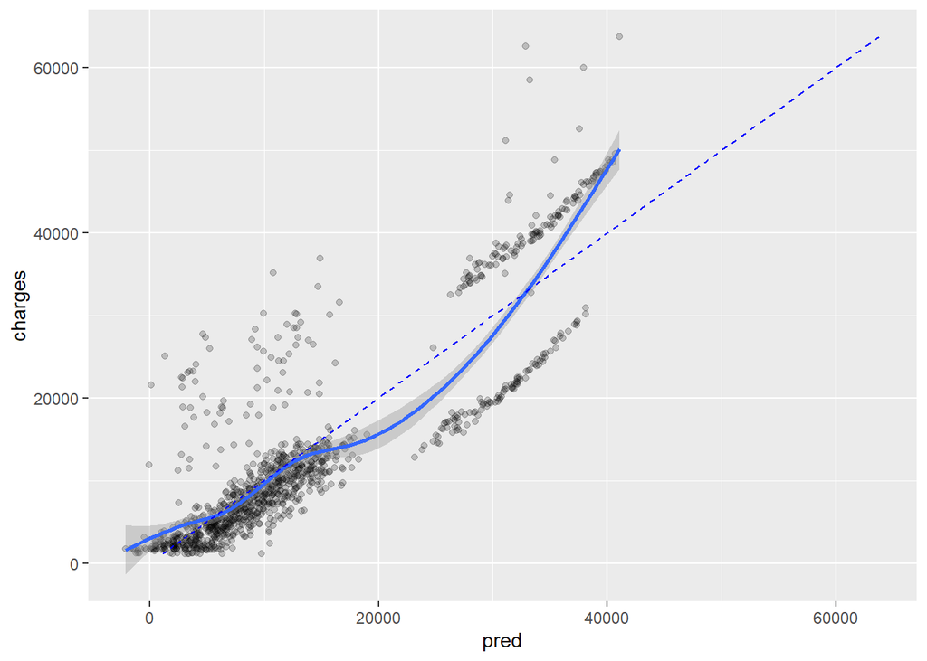

```r
ggplot(train,aes(x=pred, y=charges))+
  geom_point(alpha=0.2, col='black')+
  geom_smooth()+
  geom_line(aes(x=charges,y=charges),col='blue',linetype=2)
```

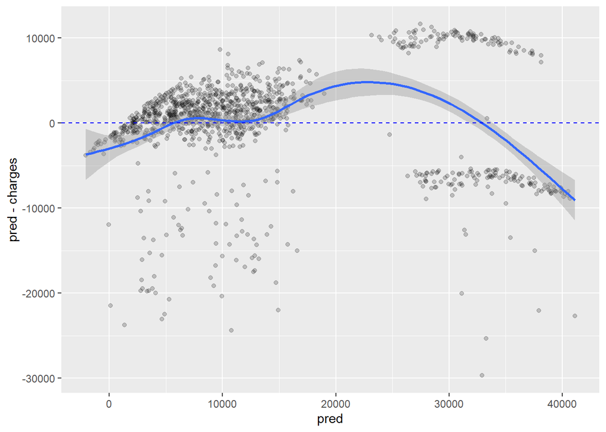

```r
ggplot(train,aes(x=pred,y=pred-charges))+
  geom_point(alpha=0.2,col='black')+
  geom_smooth()+
  geom_hline(yintercept=0,col='blue',linetype=2)
```

#### 모형 개선을 위해 다항 회귀를 할 수 도 있고, 교호작용항을 넣을 수도 있다. * lm(outcome~va1 * var2) 이렇게 설정 시 var1, var2,var1*var2 다들어감

```r
#모형개선
train$bmi30 <- ifelse(train$bmi>=30,1,0)
test$bmi30 <- ifelse(test$bmi>=30,1,0)
ins_model <- lm(charges~age+I(age^2)+sex+bmi+children+bmi30*smoker+region, train)
train$pred <- predict(ins_model,train)
test$pred <- predict(ins_model,test)

calcrmse(train$charges,train$pred)
```

```
## [1] 4430.181
```

```r
calr2(train$charges,train$pred)
```

```
## [1] 0.8682743
```

```r
calcrmse(test$charges,test$pred)
```

```
## [1] 4429.945
```

```r
calr2(test$charges,test$pred)
```

```
## [1] 0.8543864
```

```r
summary(ins_model)
```

```
##
## Call:
## lm(formula = charges ~ age + I(age^2) + sex + bmi + children +
##     bmi30 * smoker + region, data = train)
##
## Residuals:
##    Min     1Q Median     3Q    Max
##  -4450  -1624  -1276   -756  24004
##
## Coefficients:
##                   Estimate Std. Error t value Pr(>|t|)
## (Intercept)       827.7431  1518.6340   0.545   0.5858
## age               -27.9495    66.1825  -0.422   0.6729
## I(age^2)            3.6190     0.8239   4.393 1.23e-05 ***
## sexmale          -536.7356   271.6072  -1.976   0.0484 *
## bmi                89.7257    38.1995   2.349   0.0190 *
## children          576.4314   119.8630   4.809 1.73e-06 ***
## bmi30            -559.9583   473.1502  -1.183   0.2369
## smokeryes       13614.6556   485.7995  28.025  < 2e-16 ***
## regionnorthwest   -38.9878   386.2298  -0.101   0.9196
## regionsoutheast  -643.6536   389.8728  -1.651   0.0990 .
## regionsouthwest -1137.8119   388.7867  -2.927   0.0035 **
## bmi30:smokeryes 19717.6254   666.5885  29.580  < 2e-16 ***
## ---
## Signif. codes:  0 '***' 0.001 '**' 0.01 '*' 0.05 '.' 0.1 ' ' 1
##
## Residual standard error: 4455 on 1078 degrees of freedom
## Multiple R-squared:  0.8683, Adjusted R-squared:  0.8669
## F-statistic:   646 on 11 and 1078 DF,  p-value: < 2.2e-16
```

###logistic medel * log(odds)= log(p/(1-p)) * log(p/(1-p))= ax + b -> p = 1/(1+e^(-(ax+b))) * 회귀식 ax+b 가 0보다 크냐 작으냐에 따라 달라진다

```r
#data load
load(url('https://github.com/hbchoi/SampleData/raw/master/NatalRiskData.rData'))
str(sdata)
```

```
## 'data.frame':    26313 obs. of  15 variables:
##  $ PWGT         : int  155 140 151 118 134 117 160 98 132 135 ...
##  $ UPREVIS      : int  14 13 15 4 11 18 1 8 15 7 ...
##  $ CIG_REC      : logi  FALSE FALSE FALSE FALSE FALSE FALSE ...
##  $ GESTREC3     : Factor w/ 2 levels ">= 37 weeks",..: 1 1 1 1 1 1 2 1 1 2 ...
##  $ DPLURAL      : Factor w/ 3 levels "single","triplet or higher",..: 1 1 1 1 1 1 1 1 1 1 ...
##  $ ULD_MECO     : logi  TRUE FALSE FALSE FALSE FALSE TRUE ...
##  $ ULD_PRECIP   : logi  FALSE FALSE FALSE FALSE FALSE FALSE ...
##  $ ULD_BREECH   : logi  FALSE FALSE FALSE FALSE FALSE FALSE ...
##  $ URF_DIAB     : logi  FALSE FALSE FALSE FALSE FALSE FALSE ...
##  $ URF_CHYPER   : logi  FALSE FALSE FALSE FALSE FALSE FALSE ...
##  $ URF_PHYPER   : logi  FALSE FALSE FALSE FALSE FALSE FALSE ...
##  $ URF_ECLAM    : logi  FALSE FALSE FALSE FALSE FALSE FALSE ...
##  $ atRisk       : logi  FALSE FALSE FALSE FALSE FALSE FALSE ...
##  $ DBWT         : int  3714 3715 3447 3175 4038 3410 2981 3065 2948 2313 ...
##  $ ORIGRANDGROUP: int  2 4 2 6 10 7 2 7 9 6 ...
```

```r
#train test set
train <- sdata[sdata$ORIGRANDGROUP<=5,]
test <- sdata[sdata$ORIGRANDGROUP>5,]
#variable setting
complications <- c('ULD_MECO','ULD_PRECIP','ULD_BREECH')
riskfactors <- c('URF_DIAB','URF_CHYPER','URF_PHYPER','URF_ECLAM')
y <- 'atRisk'
x <- c('PWGT','UPREVIS','CIG_REC','GESTREC3','DPLURAL',complications,riskfactors)
fmla <- paste(y,paste(x,collapse='+'),sep='~')
fmla
```

```
## [1] "atRisk~PWGT+UPREVIS+CIG_REC+GESTREC3+DPLURAL+ULD_MECO+ULD_PRECIP+ULD_BREECH+URF_DIAB+URF_CHYPER+URF_PHYPER+URF_ECLAM"
```

```r
#logistic model
model <- glm(fmla,data=train,family=binomial(link='logit'))
train$pred <- predict(model,newdata=train,type='response') #newdata=예측하고자하는 데이터
test$pred <-predict(model,newdata=test,type='response') #type='response'로 해주어야 확률값이 나옴
#예측된 값 보기
test[20:40,c('pred','atRisk')]
```

```
##             pred atRisk
## 2185 0.011507461  FALSE
## 2188 0.058792989  FALSE
## 2189 0.063196603  FALSE
## 2192 0.022661796  FALSE
## 2193 0.050933807   TRUE
## 2194 0.012455440  FALSE
## 2195 0.012204660   TRUE
## 2196 0.011317563  FALSE
## 2204 0.002147274  FALSE
## 2207 0.062311633  FALSE
## 2210 0.007884831  FALSE
## 2211 0.008353482  FALSE
## 2212 0.060224116  FALSE
## 2213 0.009169627  FALSE
## 2217 0.008296810  FALSE
## 2219 0.008113151  FALSE
## 2220 0.009405842  FALSE
## 2221 0.022770689  FALSE
## 2228 0.007739053  FALSE
## 2230 0.042138774  FALSE
## 2234 0.031464647  FALSE
```

```r
aggregate(pred~atRisk,data=train,mean)
```

```
##   atRisk       pred
## 1  FALSE 0.01853135
## 2   TRUE 0.05381493
```

```r
aggregate(pred~atRisk,data=test,mean)
```

```
##   atRisk       pred
## 1  FALSE 0.01938838
## 2   TRUE 0.04997396
```

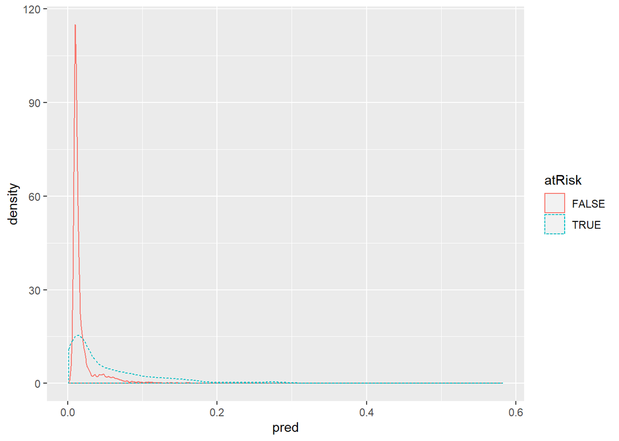

```r
ggplot(train, aes(x=pred,color=atRisk,linetype=atRisk))+geom_density()
```

```r
#threshold에 대한 pnull-> 전체에 적용했을 때 확률, 1000명 전체에 응급대처했을 때 20명0.02, -> 그래서 threshold를 적용해서 예측했을 때 맞을 확률이 얼마나 높은지 확인하는거
#p/pnull=enrich
```

## 데이터과학 15주차 강의노트

###군집분석 * unsupervised method는 명확한 판단기준은 없음 * Total within sum of square(wss): centroid와 군집내 변수들간의 거리 제곱의 평균, 작을 수록 좋다. cluster 개수가 많을 수록 값이 낮아지는 한계점이 있음 * Calinski-Harabasz index: (Bss(k)/k-1)/(wss(k)/n-k) |Between sum of square(bss)= tss-wss

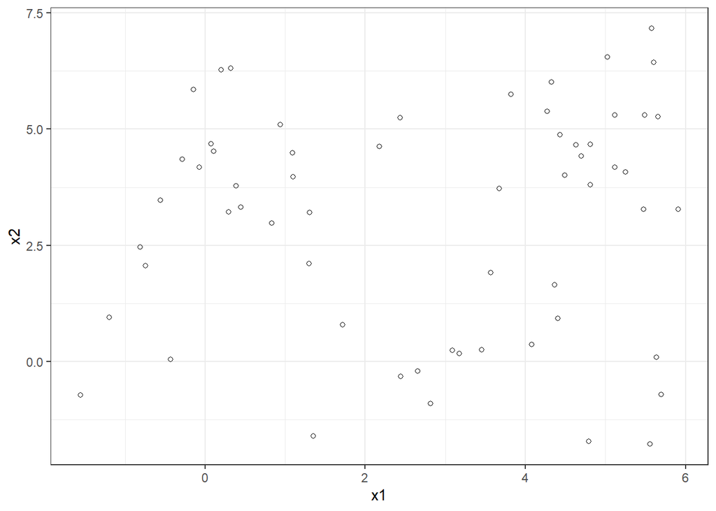

```r
#데이터셋 만들기
set.seed(2020)
synth.data<-data.frame(x1 =c(rnorm(20, 3, 1.5), rnorm(20,0,1), rnorm(20,5,1)),
                       x2 =c(rnorm(20, 0, 1), rnorm(20,4,1), rnorm(20,5,1)))
ndata<-nrow(synth.data)#행개수
ndim<-ncol(synth.data)#열개수
synth.data%>%ggplot(aes(x =x1, y=x2)) +geom_point(shape =1) +theme_bw()
```

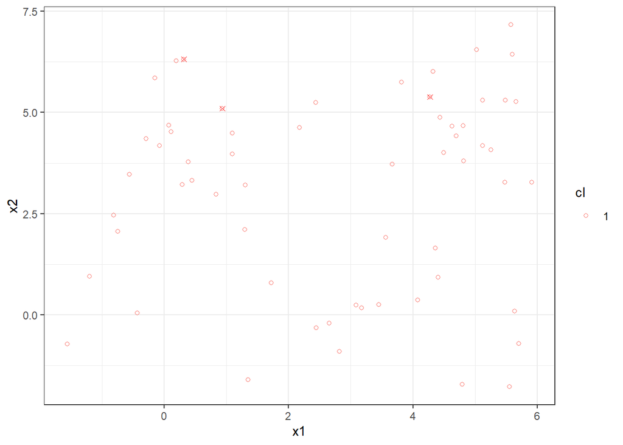

```r
#유클리디안거리 함수
u_dist<-function(u, v){sqrt(sum((u -v) **2))}
#초기 central 값
set.seed(2020)
k <-3
cents <-data.frame(cl=1:k)
cents <-cbind(cents, synth.data[sample(1:60, k),])

#군집분석 plot
synth.data$cl<-factor(rep(1, ndata), levels =1:k)
synth.data%>%ggplot(aes(x =x1, y=x2, col =cl)) +geom_point(shape =1) +theme_bw() +geom_point(data =cents, shape =4, col ='red')
```

```r
#군집분석 반복문
while(TRUE){
  # data assignment to cluster
  new_cl<-apply(synth.data[,1:ndim], 1, function(x) {
    which.min(
      apply(cents[,-1], 1, function(y) {
        u_dist(y, x)
      })
    )
  })
  if(all(synth.data$cl==factor(new_cl))) break

  synth.data$cl<-factor(new_cl)
  cents <-synth.data%>%group_by(cl)%>%
    summarise(x1 =mean(x1), x2 =mean(x2))
}

#군집분석 전처리
protein <-read.table("C:/Users/user/Documents/github_Rstudio_workspace/Data/protein.txt", sep="\t", header=TRUE)
vars.to.use<-colnames(protein)[-1] #나라 없애기
pmatrix<-scale(protein[,vars.to.use]) #  표준화
pcenter<-attr(pmatrix, "scaled:center") # 평균 저장
pscale<-attr(pmatrix, "scaled:scale") #표준편차 저장
#군집분석
pclusters<-kmeans(pmatrix, 5, nstart=100, iter.max=100) # 2번쨰=k값, 100번반복하겠다
summary(pclusters)
```

```
##              Length Class  Mode
## cluster      25     -none- numeric
## centers      45     -none- numeric
## totss         1     -none- numeric
## withinss      5     -none- numeric
## tot.withinss  1     -none- numeric
## betweenss     1     -none- numeric
## size          5     -none- numeric
## iter          1     -none- numeric
## ifault        1     -none- numeric
```

```r
pclusters$centers # 각각 군집의 편균값 어떤 특징인지 볼 수 있음
```

```
##        RedMeat  WhiteMeat        Eggs       Milk       Fish    Cereals
## 1 -0.508801956 -1.1088009 -0.41248496 -0.8320414  0.9819154  0.1300253
## 2 -0.807569986 -0.8719354 -1.55330561 -1.0783324 -1.0386379  1.7200335
## 3 -0.570049402  0.5803879 -0.08589708 -0.4604938 -0.4537795  0.3181839
## 4  0.006572897 -0.2290150  0.19147892  1.3458748  1.1582546 -0.8722721
## 5  1.011180399  0.7421332  0.94084150  0.5700581 -0.2671539 -0.6877583
##       Starch       Nuts      Fr.Veg
## 1 -0.1842010  1.3108846  1.62924487
## 2 -1.4234267  0.9961313 -0.64360439
## 3  0.7857609 -0.2679180  0.06873983
## 4  0.1676780 -0.9553392 -1.11480485
## 5  0.2288743 -0.5083895  0.02161979
```

```r
pclusters$size # 각 군집당 몇개인가
```

```
## [1] 4 4 5 4 8
```

```r
#지표 추출
pclusters$withinss
```

```
## [1] 18.925874  8.012133 16.994661  5.900318 22.110431
```

```r
(wss<-sum(pclusters$withinss))
```

```
## [1] 71.94342
```

```r
(tss<-pclusters$totss)
```

```
## [1] 216
```

```r
(bss<-pclusters$betweenss)
```

```
## [1] 144.0566
```

```r
ch.index<-(bss/(k-1)) /(wss/(ndata-k))
print(sprintf('CH index of this clustering is %.f', ch.index))
```

```
## [1] "CH index of this clustering is 57"
```